# Project Code

JAG

Author

Grace Gormley, Alexa Pryor, and Jenna Krinsky

Published

December 9, 2025

Abstract

*This file contains the code for the project on Divvy Bikes, as part of the STAT303-1-Sec20 course in Fall 2025*.

```python
#importing packages from textbook

import pandas as pd
import numpy as np

import pandas as pd
import matplotlib
import matplotlib.pyplot as plt
import seaborn as sns

# Configure matplotlib for better display in Jupyter
%matplotlib inline

# Set default figure size for all plots (width, height in inches)
import matplotlib
matplotlib.rcParams['figure.figsize'] = (8, 5)  # Larger default size
matplotlib.rcParams['figure.dpi'] = 100          # Resolution
matplotlib.rcParams['font.size'] = 11            # Default font size

# Configure Seaborn style
sns.set_palette("deep")                          # Colorblind-friendly palette
sns.set_context("notebook")                      # Appropriate scaling

#for geospacial plotting
import warnings
# Suppress all non-critical warnings
warnings.filterwarnings("ignore")
import geopandas as gpd
import geopandas
import folium
import geodatasets
```

# 1 Data quality check / cleaning / preparation

Put code with comments. The comments should explain the code such that it can be easily understood. You may put text *(in a markdown cell)* before a large chunk of code to explain the overall purpose of the code, if it is not intuitive. **Put the name of the person / persons who contributed to each code chunk / set of code chunks.** An example is given below.

## 1.1 Jenna’s Section

### 1.1.1 Importing Data

*By Jenna Krinsky*

```python
#Using Divvy Data from 2024 - 2025 (as of October)
#ChatGPT gave a way to read/combine all datasets without having to merge and import each individually


import glob

files = glob.glob("/Users/jennakrinsky/Desktop/STAT 303_1/Final/DivvyData/*.csv")

dfs = []                                      # empty list to store DataFrames
for f in files:
    dfs.append(pd.read_csv(f))

divvy = pd.concat(dfs, ignore_index=True)
```

```python
#chronological order (same as Grace)
divvy["started_at"] = pd.to_datetime(divvy["started_at"], format="mixed")
divvy = divvy.sort_values(by="started_at")
```

```python
divvy.head()
```

|  | ride_id | rideable_type | started_at | ended_at | start_station_name | start_station_id | end_station_name | end_station_id | start_lat | start_lng | end_lat | end_lng | member_casual |
| --- | --- | --- | --- | --- | --- | --- | --- | --- | --- | --- | --- | --- | --- |
| 3486147 | 6A9D809ABDF70617 | electric_bike | 2024-01-01 00:00:39 | 2024-01-01 00:07:56 | NaN | NaN | Clark St & Wrightwood Ave | TA1305000014 | 41.950000 | -87.650000 | 41.929546 | -87.643118 | member |
| 3491360 | 26B9F6E416A68EBA | electric_bike | 2024-01-01 00:00:50 | 2024-01-01 00:04:20 | NaN | NaN | NaN | NaN | 41.900000 | -87.620000 | 41.900000 | -87.620000 | casual |
| 3486040 | 30EF016A0DF5ECEE | electric_bike | 2024-01-01 00:00:52 | 2024-01-01 00:04:25 | NaN | NaN | NaN | NaN | 41.900000 | -87.620000 | 41.900000 | -87.620000 | casual |
| 3467452 | 0D9E85F804C85828 | electric_bike | 2024-01-01 00:00:53 | 2024-01-01 00:22:30 | Clinton St & Madison St | TA1305000032 | NaN | NaN | 41.881909 | -87.641296 | 41.890000 | -87.620000 | member |
| 3410785 | 56F5C3ED5178C131 | classic_bike | 2024-01-01 00:01:01 | 2024-01-01 00:24:12 | LaSalle St & Illinois St | 13430 | Indiana Ave & Roosevelt Rd | SL-005 | 41.890762 | -87.631697 | 41.867888 | -87.623041 | member |

```python
#import other datasets

routes0 = pd.read_csv("Bike_Routes_20251206.csv")
stations = pd.read_csv("Divvy_Bicycle_Stations_20251206.csv")
boundaries = pd.read_csv("CensusTractsTIGER2010_20251206.csv")
demographic = pd.read_csv("ACS_5_Year_Data_by_Community_Area_-_Most_Recent_Year_20251206.csv")
```

```python
routes0.head()
```

|  | the_geom | STREET | ST_NAME | ONEWAY_DIR | F_STREET | T_STREET | DISPLAYROU | MI_CTRLINE | BR_ONEWAY | BR_OW_DIR | CONTRAFLOW |
| --- | --- | --- | --- | --- | --- | --- | --- | --- | --- | --- | --- |
| 0 | MULTILINESTRING ((-87.70296713856047 41.771674... | MARQUETTE RD | MARQUETTE | - | S CENTRAL PARK AVE | S KEDZIE AVE | BUFFERED | 0.495171 | NaN | NaN | NaN |
| 1 | MULTILINESTRING ((-87.69808324194773 41.771749... | MARQUETTE RD | MARQUETTE | - | S KEDZIE AVE | S SACRAMENTO AVE | SHARED | 0.252404 | NaN | NaN | NaN |
| 2 | MULTILINESTRING ((-87.54814956426897 41.751975... | LAKE SHORE DR | LAKE SHORE | - | E 87TH ST | E 79TH ST | BUFFERED | 1.244230 | NaN | NaN | NaN |
| 3 | MULTILINESTRING ((-87.63381261441066 41.881289... | WELLS ST | WELLS | S | W VAN BUREN ST | W WACKER DR | SHARED | 0.696352 | Y | S | NaN |
| 4 | MULTILINESTRING ((-87.59169592896838 41.795509... | 55TH PL | 55TH | W | S DORCHESTER AVE | E 55TH ST | BUFFERED | 0.140521 | Y | W | NaN |

```python
stations.head()
```

|  | ID | Station Name | Short Name | Total Docks | Docks in Service | Status | Latitude | Longitude | Location |
| --- | --- | --- | --- | --- | --- | --- | --- | --- | --- |
| 0 | 1859717767703464460 | Kedzie Ave & Redfield Dr | CHI01795 | 15 | 15 | In Service | 41.765230 | -87.703160 | POINT (-87.70316 41.76523) |
| 1 | 1861588043429399408 | McCormick Blvd & Devon Ave | CHI01881 | 11 | 11 | In Service | 41.997200 | -87.711050 | POINT (-87.71105 41.9972) |
| 2 | a3af1767-a135-11e9-9cda-0a87ae2ba916 | Broadway & Granville Ave | CHI00563 | 23 | 23 | In Service | 41.994780 | -87.660285 | POINT (-87.6602845349 41.9947796884) |
| 3 | a3aa91f4-a135-11e9-9cda-0a87ae2ba916 | Greenview Ave & Diversey Pkwy | CHI00382 | 15 | 15 | In Service | 41.932590 | -87.665936 | POINT (-87.665936350822 41.932589634298) |
| 4 | a3aa9732-a135-11e9-9cda-0a87ae2ba916 | Loomis St & Lexington St | CHI00238 | 20 | 20 | In Service | 41.872229 | -87.661364 | POINT (-87.661363855004 41.87222873224) |

```python
boundaries.head()
```

|  | the_geom | STATEFP10 | COUNTYFP10 | TRACTCE10 | GEOID10 | NAME10 | NAMELSAD10 | COMMAREA | COMMAREA_N | NOTES |
| --- | --- | --- | --- | --- | --- | --- | --- | --- | --- | --- |
| 0 | MULTIPOLYGON (((-87.62404799998049 41.73021699... | 17 | 31 | 842400 | 17031842400 | 8424.0 | Census Tract 8424 | 44 | 44 | NaN |
| 1 | MULTIPOLYGON (((-87.6860799999848 41.822956000... | 17 | 31 | 840300 | 17031840300 | 8403.0 | Census Tract 8403 | 59 | 59 | NaN |
| 2 | MULTIPOLYGON (((-87.62934700001182 41.85279700... | 17 | 31 | 841100 | 17031841100 | 8411.0 | Census Tract 8411 | 34 | 34 | NaN |
| 3 | MULTIPOLYGON (((-87.68813499997718 41.85569099... | 17 | 31 | 841200 | 17031841200 | 8412.0 | Census Tract 8412 | 31 | 31 | NaN |
| 4 | MULTIPOLYGON (((-87.63312200003458 41.87448800... | 17 | 31 | 839000 | 17031839000 | 8390.0 | Census Tract 8390 | 32 | 32 | NaN |

```python
demographic.head()
```

|  | ACS Year | Community Area | Under $25,000 | $25,000 to $49,999 | $50,000 to $74,999 | $75,000 to $125,000 | $125,000 + | Male 0 to 17 | Male 18 to 24 | Male 25 to 34 | ... | White | Black or African American | American Indian or Alaska Native | Asian | Native Hawaiian or Pacific Islander | Other Race | Multiracial | White Not Hispanic or Latino | Hispanic or Latino | Record ID |
| --- | --- | --- | --- | --- | --- | --- | --- | --- | --- | --- | --- | --- | --- | --- | --- | --- | --- | --- | --- | --- | --- |
| 0 | 2023 | ALBANY PARK | 1,269 | 1,916 | 1,801 | 2,306 | 3,379 | 4,799 | 2,955 | 4,513 | ... | 21,496 | 2,228 | 759 | 7,124 | 1 | 7,888 | 8,334 | 16,115 | 21,108 | 2023_ALBANY PARK |
| 1 | 2023 | ARCHER HEIGHTS | 223 | 752 | 441 | 795 | 739 | 1,927 | 732 | 1,102 | ... | 6,232 | 10 | 108 | 679 | 0 | 3,705 | 3,142 | 2,043 | 11,097 | 2023_ARCHER HEIGHTS |
| 2 | 2023 | ARMOUR SQUARE | 701 | 798 | 370 | 637 | 597 | 1,300 | 487 | 871 | ... | 2,556 | 1,487 | 107 | 8,402 | 61 | 212 | 325 | 2,226 | 565 | 2023_ARMOUR SQUARE |
| 3 | 2023 | ASHBURN | 797 | 1,351 | 1,985 | 3,014 | 2,735 | 5,150 | 1,964 | 2,881 | ... | 11,297 | 18,124 | 697 | 436 | 0 | 7,772 | 4,517 | 3,774 | 19,917 | 2023_ASHBURN |
| 4 | 2023 | AUBURN GRESHAM | 2,541 | 2,451 | 1,592 | 2,202 | 1,850 | 5,803 | 1,836 | 2,964 | ... | 760 | 43,414 | 119 | 399 | 0 | 993 | 798 | 491 | 1,577 | 2023_AUBURN GRESHAM |

5 rows × 30 columns

```python
demographic.shape
```

```
(77, 30)
```

### 1.1.2 Data cleaning

*By Jenna Krinsky*

```python
#...Code with comments...#
print(divvy.shape)
divvy.isnull().sum()
```

```
(10916400, 13)
```

```
ride_id                     0
rideable_type               0
started_at                  0
ended_at                    0
start_station_name    2155418
start_station_id      2155418
end_station_name      2236017
end_station_id        2236017
start_lat                   0
start_lng                   0
end_lat                 12288
end_lng                 12288
member_casual               0
dtype: int64
```

```python
print(routes0.shape)
routes0.isnull().sum()
```

```
(931, 11)
```

```
the_geom        0
STREET          0
ST_NAME         0
ONEWAY_DIR      0
F_STREET        0
T_STREET        0
DISPLAYROU      0
MI_CTRLINE      0
BR_ONEWAY     811
BR_OW_DIR     811
CONTRAFLOW    869
dtype: int64
```

Since the majority of rows, do not contain data on BR_ONEWAY, BR_OW_DIR, or CONTRAFLOW, we can clean the data simply through making a different dataset that excludes those rows.

```python
routes = routes0[["the_geom", "STREET", "ST_NAME", "ONEWAY_DIR", "F_STREET", "T_STREET", "DISPLAYROU", "MI_CTRLINE"]]
```

```python
routes.isnull().sum()
```

```
the_geom      0
STREET        0
ST_NAME       0
ONEWAY_DIR    0
F_STREET      0
T_STREET      0
DISPLAYROU    0
MI_CTRLINE    0
dtype: int64
```

```python
print(stations.shape)
stations.isnull().sum()
```

```
(1149, 9)
```

```
ID                   0
Station Name         0
Short Name          99
Total Docks          0
Docks in Service     0
Status               0
Latitude             0
Longitude            0
Location             0
dtype: int64
```

```python
print(demographic.shape)
demographic.isnull().sum()
```

```
(77, 30)
```

```
ACS Year                               0
Community Area                         0
Under $25,000                          0
$25,000 to $49,999                     0
$50,000 to $74,999                     0
$75,000 to $125,000                    0
$125,000 +                             0
Male 0 to 17                           0
Male 18 to 24                          0
Male 25 to 34                          0
Male 35 to 49                          0
Male 50 to 64                          0
Male 65+                               0
Female 0 to 17                         0
Female 18 to 24                        0
Female 25 to 34                        0
Female 35 to 49                        0
Female 50 to 64                        0
Female 65 +                            0
Total Population                       0
White                                  0
Black or African American              0
American Indian or Alaska Native       0
Asian                                  0
Native Hawaiian or Pacific Islander    0
Other Race                             0
Multiracial                            0
White Not Hispanic or Latino           0
Hispanic or Latino                     0
Record ID                              0
dtype: int64
```

```python
demographic["Community Area"]
```

```
0        ALBANY PARK
1     ARCHER HEIGHTS
2      ARMOUR SQUARE
3            ASHBURN
4     AUBURN GRESHAM
           ...
72         WEST LAWN
73      WEST PULLMAN
74        WEST RIDGE
75         WEST TOWN
76          WOODLAWN
Name: Community Area, Length: 77, dtype: object
```

Overall, the datasets were clean. Although there are missing values in the Divvy dataset, they are mainly categorical variables (Station Names) so they cannot be filled in based on imputation. End Lat/Long are missing for .1% of entries so that does not impact the dataset.

#### 1.1.2.1 Configuring Neighborhoods

*By Jenna Krinsky*

##### 1.1.2.1.1 Visualizing Chicago

*By Jenna Krinsky*

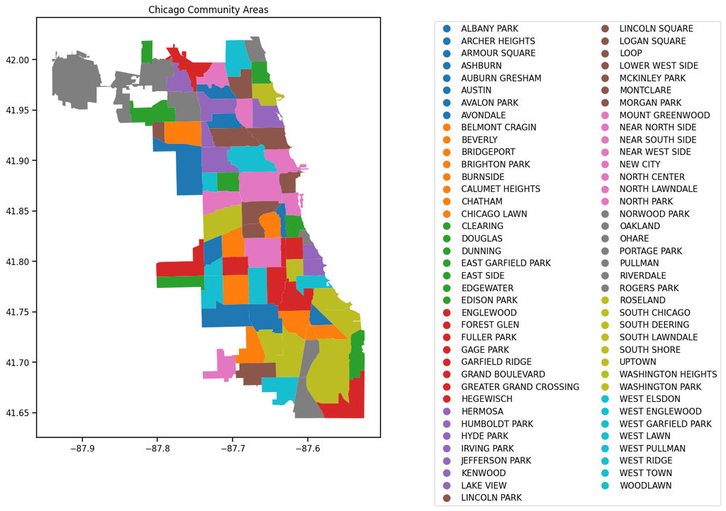

```python
#FROM TEXTBOOK

# Create figure and axis
fig, ax = plt.subplots(figsize=(15, 10))

# Plot your GeoDataFrame
chicago0 = gpd.read_file(r'/Users/jennakrinsky/Desktop/STAT 303_1/Final/Boundaries - Community Areas_20251206/geo_export_4e5b8e79-ef2a-4393-97e4-7e19e27e3265.shp')
chicago0.plot(column='community', ax=ax, legend=True, legend_kwds={'ncol': 2, 'bbox_to_anchor': (2, 1)})

# Add title (optional)
plt.title('Chicago Community Areas');
```

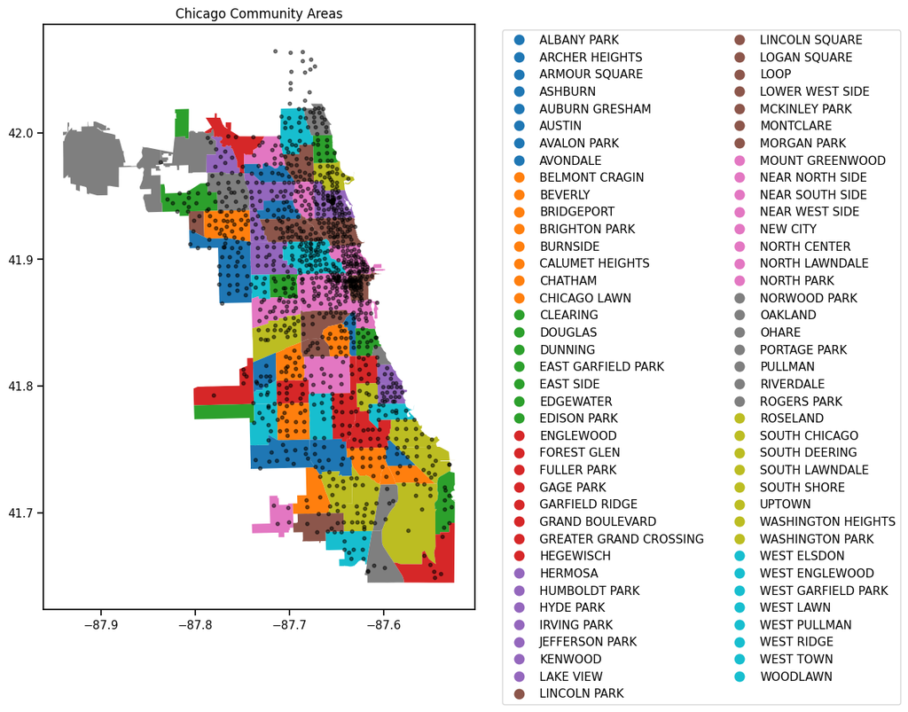

```python
# Adding the stations to the plot
fig, ax = plt.subplots(figsize=(15, 10))

chicago = gpd.read_file(r'/Users/jennakrinsky/Desktop/STAT 303_1/Final/Boundaries - Community Areas_20251206/geo_export_4e5b8e79-ef2a-4393-97e4-7e19e27e3265.shp')
chicago.plot(column='community', ax=ax, legend=True, legend_kwds={'ncol': 2, 'bbox_to_anchor': (2, 1)})

plt.scatter(stations['Longitude'], stations['Latitude'], s=10, alpha=0.5, color='black', marker='o')
plt.title('Chicago Community Areas');
```

There are stations North of the city limits. I want to delete these from the dataset to clean it in order to do the rest of my analysis.

```python
#Cleaning stations so that they are only within the Chicago boundaries

minx, miny, maxx, maxy = chicago.total_bounds

stations_clean = stations[
    (stations['Longitude'] >= minx) &
    (stations['Longitude'] <= maxx) &
    (stations['Latitude']  >= miny) &
    (stations['Latitude']  <= maxy)
]
```

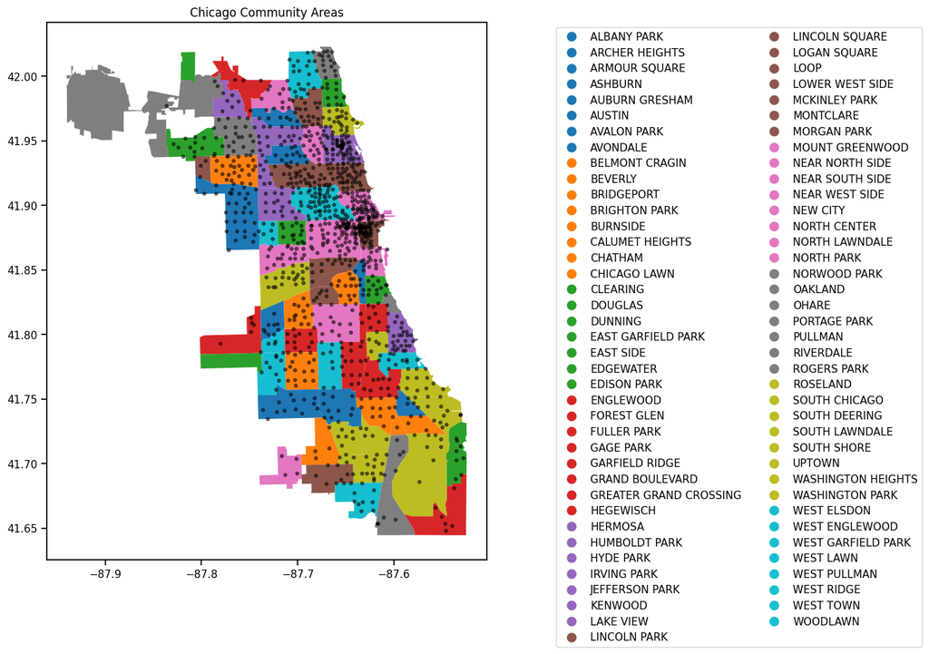

```python
fig, ax = plt.subplots(figsize=(15, 10))

chicago = gpd.read_file(r'/Users/jennakrinsky/Desktop/STAT 303_1/Final/Boundaries - Community Areas_20251206/geo_export_4e5b8e79-ef2a-4393-97e4-7e19e27e3265.shp')
chicago.plot(column='community', ax=ax, legend=True, legend_kwds={'ncol': 2, 'bbox_to_anchor': (2, 1)})

plt.scatter(stations_clean['Longitude'], stations_clean['Latitude'], s=10, alpha=0.5, color='black', marker='o')
plt.title('Chicago Community Areas');
```

Now all stations are within the city limits!

### 1.1.3 Merging Data

*By Jenna Krinsky*

```python
demographic.head()
```

|  | ACS Year | Community Area | Under $25,000 | $25,000 to $49,999 | $50,000 to $74,999 | $75,000 to $125,000 | $125,000 + | Male 0 to 17 | Male 18 to 24 | Male 25 to 34 | ... | White | Black or African American | American Indian or Alaska Native | Asian | Native Hawaiian or Pacific Islander | Other Race | Multiracial | White Not Hispanic or Latino | Hispanic or Latino | Record ID |
| --- | --- | --- | --- | --- | --- | --- | --- | --- | --- | --- | --- | --- | --- | --- | --- | --- | --- | --- | --- | --- | --- |
| 0 | 2023 | ALBANY PARK | 1,269 | 1,916 | 1,801 | 2,306 | 3,379 | 4,799 | 2,955 | 4,513 | ... | 21,496 | 2,228 | 759 | 7,124 | 1 | 7,888 | 8,334 | 16,115 | 21,108 | 2023_ALBANY PARK |
| 1 | 2023 | ARCHER HEIGHTS | 223 | 752 | 441 | 795 | 739 | 1,927 | 732 | 1,102 | ... | 6,232 | 10 | 108 | 679 | 0 | 3,705 | 3,142 | 2,043 | 11,097 | 2023_ARCHER HEIGHTS |
| 2 | 2023 | ARMOUR SQUARE | 701 | 798 | 370 | 637 | 597 | 1,300 | 487 | 871 | ... | 2,556 | 1,487 | 107 | 8,402 | 61 | 212 | 325 | 2,226 | 565 | 2023_ARMOUR SQUARE |
| 3 | 2023 | ASHBURN | 797 | 1,351 | 1,985 | 3,014 | 2,735 | 5,150 | 1,964 | 2,881 | ... | 11,297 | 18,124 | 697 | 436 | 0 | 7,772 | 4,517 | 3,774 | 19,917 | 2023_ASHBURN |
| 4 | 2023 | AUBURN GRESHAM | 2,541 | 2,451 | 1,592 | 2,202 | 1,850 | 5,803 | 1,836 | 2,964 | ... | 760 | 43,414 | 119 | 399 | 0 | 993 | 798 | 491 | 1,577 | 2023_AUBURN GRESHAM |

5 rows × 30 columns

```python
demographic['Community Area'] = demographic['Community Area'].str.upper().str.strip()


chicago = chicago.sort_values(by = "community")
chicago['Community Area'] = chicago['community'].str.upper().str.strip()
```

```python
chicago_dem = chicago.merge(
    demographic,
    on='Community Area',
    how='left'
)
chicago_dem.head()
```

|  | area_numbe | community | area_num_1 | shape_area | shape_len | geometry | community_name | Community Area | ACS Year | Under $25,000 | ... | White | Black or African American | American Indian or Alaska Native | Asian | Native Hawaiian or Pacific Islander | Other Race | Multiracial | White Not Hispanic or Latino | Hispanic or Latino | Record ID |
| --- | --- | --- | --- | --- | --- | --- | --- | --- | --- | --- | --- | --- | --- | --- | --- | --- | --- | --- | --- | --- | --- |
| 0 | 14.0 | ALBANY PARK | 14 | 5.354223e+07 | 39339.016439 | POLYGON ((-87.70404 41.97355, -87.70403 41.973... | ALBANY PARK | ALBANY PARK | 2023 | 1,269 | ... | 21,496 | 2,228 | 759 | 7,124 | 1 | 7,888 | 8,334 | 16,115 | 21,108 | 2023_ALBANY PARK |
| 1 | 57.0 | ARCHER HEIGHTS | 57 | 5.592251e+07 | 31880.021029 | POLYGON ((-87.71437 41.82604, -87.71436 41.825... | ARCHER HEIGHTS | ARCHER HEIGHTS | 2023 | 223 | ... | 6,232 | 10 | 108 | 679 | 0 | 3,705 | 3,142 | 2,043 | 11,097 | 2023_ARCHER HEIGHTS |
| 2 | 34.0 | ARMOUR SQUARE | 34 | 2.776620e+07 | 31948.598840 | POLYGON ((-87.62917 41.84556, -87.62947 41.845... | ARMOUR SQUARE | ARMOUR SQUARE | 2023 | 701 | ... | 2,556 | 1,487 | 107 | 8,402 | 61 | 212 | 325 | 2,226 | 565 | 2023_ARMOUR SQUARE |
| 3 | 70.0 | ASHBURN | 70 | 1.354603e+08 | 54818.154632 | POLYGON ((-87.71255 41.75734, -87.71252 41.757... | ASHBURN | ASHBURN | 2023 | 797 | ... | 11,297 | 18,124 | 697 | 436 | 0 | 7,772 | 4,517 | 3,774 | 19,917 | 2023_ASHBURN |
| 4 | 71.0 | AUBURN GRESHAM | 71 | 1.050654e+08 | 46757.721716 | POLYGON ((-87.6399 41.75615, -87.6399 41.75593... | AUBURN GRESHAM | AUBURN GRESHAM | 2023 | 2,541 | ... | 760 | 43,414 | 119 | 399 | 0 | 993 | 798 | 491 | 1,577 | 2023_AUBURN GRESHAM |

5 rows × 37 columns

Now that the datasets are merged, we can make graphs based on demographics.

## 1.2 Alexa’s Section

### 1.2.1 Distribution of variables

*By Alexa Pryor*

```python
def variable_distribution(df, top_n=5):
    rows = []

    for col in df.columns:
        series = df[col]
        dtype = series.dtype

        if series.dtype == 'object' or str(dtype) == "category" or series.nunique() < 20:
                value_counts = series.value_counts(dropna=False)
                top_levels = value_counts.head(top_n)

                rows.append({
                    "variable": col,
                    "type": "categorical",
                    "n_missing": series.isna().sum(),
                    "n_unique": series.nunique(),
                    "top_levels": dict(top_levels)
                })
        else:
            rows.append({
                "variable": col,
                "type": "continuous",
                "n_missing": series.isna().sum(),
                "mean": series.mean(),
                "std": series.std(),
                "min": series.min(),
                "25%": series.quantile(0.25),
                "50%": series.median(),
                "75%": series.quantile(0.75),
                "max": series.max(),
            })

    return pd.DataFrame(rows)

# divvy data distribution
print(variable_distribution(divvy, top_n=5).to_string())
(variable_distribution(tnp, top_n=5))


#
```

[output not shown]

|  | variable | type | n_missing | n_unique | top_levels | mean | std | min | 25% | 50% | 75% | max |
| --- | --- | --- | --- | --- | --- | --- | --- | --- | --- | --- | --- | --- |
| 0 | Trip ID | categorical | 0 | 126302.0 | {'d056f64eebc0b3d338850625c9ffca529b54aa56': 1... | NaN | NaN | NaN | NaN | NaN | NaN | NaN |
| 1 | Trip Start Timestamp | categorical | 0 | 285.0 | {'01/14/2023 06:45:00 PM': 1152, '01/14/2023 0... | NaN | NaN | NaN | NaN | NaN | NaN | NaN |
| 2 | Trip End Timestamp | categorical | 0 | 288.0 | {'01/14/2023 07:00:00 PM': 1214, '01/14/2023 0... | NaN | NaN | NaN | NaN | NaN | NaN | NaN |
| 3 | Trip Seconds | categorical | 0 | 2529.0 | {'896': 188, '904': 172, '908': 171, '414': 16... | NaN | NaN | NaN | NaN | NaN | NaN | NaN |
| 4 | Trip Miles | continuous | 0 | NaN | NaN | 4.073031 | 4.053304 | 0.000000 | 1.400000 | 2.700000 | 5.000000 | 40.100000 |
| 5 | Percent Time Chicago | categorical | 0 | 4.0 | {'100%': 126251, '99%': 47, '0%': 3, '97%': 1} | NaN | NaN | NaN | NaN | NaN | NaN | NaN |
| 6 | Percent Distance Chicago | categorical | 0 | 4.0 | {'100%': 126251, '99%': 47, '0%': 3, '97%': 1} | NaN | NaN | NaN | NaN | NaN | NaN | NaN |
| 7 | Pickup Community Area | continuous | 0 | NaN | NaN | 25.229743 | 19.431742 | 1.000000 | 8.000000 | 24.000000 | 33.000000 | 77.000000 |
| 8 | Dropoff Community Area | continuous | 0 | NaN | NaN | 25.487166 | 19.670896 | 1.000000 | 8.000000 | 24.000000 | 33.000000 | 77.000000 |
| 9 | Fare | categorical | 43 | 50.0 | {'$7.5': 30882, '$10': 27401, '$12.5': 22686, ... | NaN | NaN | NaN | NaN | NaN | NaN | NaN |
| 10 | Tip | categorical | 43 | 32.0 | {'$0': 95009, '$2': 8894, '$3': 8782, '$5': 49... | NaN | NaN | NaN | NaN | NaN | NaN | NaN |
| 11 | Additional Charges | categorical | 43 | 1006.0 | {'$1.26': 103196, '$6.26': 7416, '$0.64': 3114... | NaN | NaN | NaN | NaN | NaN | NaN | NaN |
| 12 | Trip Total | categorical | 43 | 2853.0 | {'$8.76': 21793, '$11.26': 17453, '$13.76': 15... | NaN | NaN | NaN | NaN | NaN | NaN | NaN |
| 13 | Pickup Centroid Latitude | continuous | 0 | NaN | NaN | 41.886079 | 0.065178 | 41.650222 | 41.860190 | 41.893216 | 41.929047 | 42.021224 |
| 14 | Pickup Centroid Longitude | continuous | 0 | NaN | NaN | -87.658556 | 0.054659 | -87.913625 | -87.675312 | -87.650290 | -87.626215 | -87.534903 |
| 15 | Pickup Centroid Location | categorical | 0 | 816.0 | {'POINT (-87.6572331997 41.8852813201)': 3409,... | NaN | NaN | NaN | NaN | NaN | NaN | NaN |
| 16 | Dropoff Centroid Latitude | continuous | 0 | NaN | NaN | 41.886664 | 0.065277 | 41.650222 | 41.860190 | 41.893216 | 41.929047 | 42.021224 |
| 17 | Dropoff Centroid Longitude | continuous | 0 | NaN | NaN | -87.659347 | 0.056582 | -87.913625 | -87.675312 | -87.651062 | -87.626215 | -87.534903 |
| 18 | Dropoff Centroid Location | categorical | 0 | 795.0 | {'POINT (-87.6572331997 41.8852813201)': 3209,... | NaN | NaN | NaN | NaN | NaN | NaN | NaN |

### 1.2.2 Data cleaning

*Alexa Pryor*

```python
divvy['started_at'] = pd.to_datetime(divvy['started_at'])
divvy['ended_at'] = pd.to_datetime(divvy['ended_at'])
```

```python
# Helper function to clean currency columns
def clean_currency(column):
    return pd.to_numeric(column.astype(str).str.replace('$', '').str.replace(',', '').str.strip(), errors='coerce').fillna(0.0)

# Process TNP
tnp['Trip Start Timestamp'] = pd.to_datetime(tnp['Trip Start Timestamp'])
tnp_jan = tnp[tnp['Trip Start Timestamp'].dt.month == 1].copy()

# Clean object-type numeric columns to avoid the TypeError
tnp_jan['Fare'] = clean_currency(tnp_jan['Fare'])
tnp_jan['Tip'] = clean_currency(tnp_jan['Tip'])
tnp_jan['Additional Charges'] = clean_currency(tnp_jan['Additional Charges'])
tnp_jan['Trip Miles'] = pd.to_numeric(tnp_jan['Trip Miles'], errors='coerce').fillna(0)
tnp_jan['Trip Seconds'] = pd.to_numeric(tnp_jan['Trip Seconds'], errors='coerce').fillna(0)

# Process Divvy
divvy['started_at'] = pd.to_datetime(divvy['started_at'])
divvy['ended_at'] = pd.to_datetime(divvy['ended_at'])
```

### 1.2.3 Data preparation

*By Alexa Pryor*

```python
######---------------Creating new variables----------------#########
divvy['duration_mins'] = (divvy['ended_at'] - divvy['started_at']).dt.total_seconds() / 60

conditions = [
    (tnp['Pickup Community Area'] <= 22),
    (tnp['Pickup Community Area'] <= 31) & (tnp['Pickup Community Area'] > 22),
    (tnp['Pickup Community Area'] <= 33) & (tnp['Pickup Community Area'] > 31),
    (tnp['Pickup Community Area'] <= 75) & (tnp['Pickup Community Area'] > 33),

]

# Define the corresponding string values for each condition
values = ['North Side', 'West Side', 'Central', 'South Side']

# Create a new column 'category' using np.select
# The 'default' parameter handles values not meeting any condition (e.g., <= 40)
tnp['region'] = np.select(conditions, values, default='North Side')

tnp['Trip Seconds'] = pd.to_numeric(tnp['Trip Seconds'].astype(str).str.replace(',', ''), errors='coerce')
tnp = tnp.dropna(subset=['Trip Seconds'])
tnp['tnp_min'] = (tnp['Trip Seconds'] // 60).astype('int64')
divvy['min'] = ((divvy['ended_at'] - divvy['started_at']).dt.total_seconds() // 60).astype('int64')
```

```python
######-----Standardizing the dataset ----------------------#########

#### Daily Aggregation
# Aggregate TNP metrics by date
tnp_daily = tnp_jan.groupby(tnp_jan['Trip Start Timestamp'].dt.date).agg(
    tnp_rides=('Trip ID', 'size'),
    avg_tnp_fare=('Fare', 'mean'),
    avg_tnp_tip=('Tip', 'mean'),
    avg_tnp_miles=('Trip Miles', 'mean'),
    avg_tnp_seconds=('Trip Seconds', 'mean'),
    avg_tnp_charges=('Additional Charges', 'mean')
).reset_index().rename(columns={'Trip Start Timestamp': 'date'})

# Aggregate Divvy metrics by date
divvy_daily = divvy.groupby(divvy['started_at'].dt.date).agg(
    divvy_rides=('ride_id', 'size'),
    avg_divvy_duration_min=('duration_mins', 'mean'),
    casual_rides=('member_casual', lambda x: (x == 'casual').sum()),
    member_rides=('member_casual', lambda x: (x == 'member').sum())
).reset_index().rename(columns={'started_at': 'date'})

# Aggregate Divvy metrics by date
divvy_daily = divvy.groupby(divvy['started_at'].dt.date).agg(
    divvy_rides=('ride_id', 'size'),
    avg_divvy_duration_min=('duration_mins', 'mean'),
    casual_rides=('member_casual', lambda x: (x == 'casual').sum()),
    member_rides=('member_casual', lambda x: (x == 'member').sum())
).reset_index().rename(columns={'started_at': 'date'})

# 4. Merge dataframes
final_df = pd.merge(divvy_daily, tnp_daily, on='date', how='inner')
corr_matrix = final_df.drop(columns=['date']).corr()
```

```python
#### Hourly Aggregation
tnp['start_time'] = pd.to_datetime(tnp['Trip Start Timestamp'])
tnp_jan = tnp[tnp['start_time'].dt.month == 1].copy()
tnp_jan['hour_bin'] = tnp_jan['start_time'].dt.floor('H')

# Clean object-type numeric columns to avoid the TypeError
tnp_jan['Fare'] = clean_currency(tnp_jan['Fare'])
tnp_jan['Tip'] = clean_currency(tnp_jan['Tip'])
tnp_jan['Additional Charges'] = clean_currency(tnp_jan['Additional Charges'])
tnp_jan['Trip Miles'] = pd.to_numeric(tnp_jan['Trip Miles'], errors='coerce').fillna(0)
tnp_jan['Trip Seconds'] = pd.to_numeric(tnp_jan['Trip Seconds'], errors='coerce').fillna(0)

tnp_hourly = tnp_jan.groupby('hour_bin').agg(
    tnp_ride_count=('Trip ID', 'size'),
    avg_tnp_fare=('Fare', 'mean'),
    avg_tnp_miles=('Trip Miles', 'mean'),
    avg_tnp_seconds=('Trip Seconds', 'mean'),
    avg_tnp_tips=('Tip', 'mean')
).reset_index()

# 3. Hourly Divvy Aggregation (Jan 2023)
divvy['start_time'] = pd.to_datetime(divvy['started_at'])
divvy['ended_at'] = pd.to_datetime(divvy['ended_at'])
divvy['hour_bin'] = divvy['start_time'].dt.floor('H')
divvy['duration_mins'] = (divvy['ended_at'] - divvy['start_time']).dt.total_seconds() / 60

divvy_hourly = divvy.groupby('hour_bin').agg(
    divvy_ride_count=('ride_id', 'size'),
    avg_divvy_duration=('duration_mins', 'mean'),
    divvy_casual_perc=('member_casual', lambda x: (x == 'casual').mean())
).reset_index()

# 4. Merging on Hour Timestamp
merged_hourly = pd.merge(divvy_hourly, tnp_hourly, on='hour_bin', how='inner')
```

## 1.3 Grace’s Section

### 1.3.1 Importing each dataset

```python
#Making my divvy dataset from 2024-2025
import glob #gonna be honest, I got this from chat so I dont need to do it one by one (i'm combining each month from 12/25 to 1/24)

files = glob.glob("/Users/gracegormley/Desktop/Stat 303-1/project/divvy 2024-2025/*.csv")   # grabs all CSVs in the folder

dfs = []                                      # empty list to store DataFrames
for f in files:
    dfs.append(pd.read_csv(f))

divvy = pd.concat(dfs, ignore_index=True)
```

```python
#make sure they're in chronological order
divvy["started_at"] = pd.to_datetime(divvy["started_at"], format="mixed")
divvy = divvy.sort_values(by="started_at")
```

```python
#Importing my extra datasets
traffic = pd.read_csv('/Users/gracegormley/Desktop/Stat 303-1/project/Chicago_Traffic_Tracker_-_Congestion_Estimates_by_Segments_20251125.csv')
bus_stops = pd.read_csv('/Users/gracegormley/Desktop/Stat 303-1/project/CTA_BusStops_20251125.csv')
L_stops = pd.read_csv('/Users/gracegormley/Desktop/Stat 303-1/project/CTA_-_System_Information_-_List_of_\'L\'_Stops_20251125.csv')
population = pd.read_csv('/Users/gracegormley/Desktop/Stat 303-1/project/ACS_5_Year_Data_by_Community_Area.csv') #this isn't from chicago, since they organize pop by zip code. Someone already sorted them, so I'm using their data: https://www.kaggle.com/datasets/aniket0712/acs-5-year-data-by-community-area/code
bike_stations = pd.read_csv('/Users/gracegormley/Desktop/Stat 303-1/project/Divvy_Bicycle_Stations_20251201.csv')
```

#### 1.3.1.1 Taking a look at each dataset

```python
#Printing the head of each dataset to get an idea of the contents
```

```python
divvy.head()
```

|  | ride_id | rideable_type | started_at | ended_at | start_station_name | start_station_id | end_station_name | end_station_id | start_lat | start_lng | end_lat | end_lng | member_casual |
| --- | --- | --- | --- | --- | --- | --- | --- | --- | --- | --- | --- | --- | --- |
| 3486147 | 6A9D809ABDF70617 | electric_bike | 2024-01-01 00:00:39 | 2024-01-01 00:07:56 | NaN | NaN | Clark St & Wrightwood Ave | TA1305000014 | 41.950000 | -87.650000 | 41.929546 | -87.643118 | member |
| 3491360 | 26B9F6E416A68EBA | electric_bike | 2024-01-01 00:00:50 | 2024-01-01 00:04:20 | NaN | NaN | NaN | NaN | 41.900000 | -87.620000 | 41.900000 | -87.620000 | casual |
| 3486040 | 30EF016A0DF5ECEE | electric_bike | 2024-01-01 00:00:52 | 2024-01-01 00:04:25 | NaN | NaN | NaN | NaN | 41.900000 | -87.620000 | 41.900000 | -87.620000 | casual |
| 3467452 | 0D9E85F804C85828 | electric_bike | 2024-01-01 00:00:53 | 2024-01-01 00:22:30 | Clinton St & Madison St | TA1305000032 | NaN | NaN | 41.881909 | -87.641296 | 41.890000 | -87.620000 | member |
| 3410785 | 56F5C3ED5178C131 | classic_bike | 2024-01-01 00:01:01 | 2024-01-01 00:24:12 | LaSalle St & Illinois St | 13430 | Indiana Ave & Roosevelt Rd | SL-005 | 41.890762 | -87.631697 | 41.867888 | -87.623041 | member |

```python
traffic.head()
```

|  | SEGMENTID | STREET | DIRECTION | FROM_STREET | TO_STREET | LENGTH | STREET_HEADING | COMMENTS | START_LONGITUDE | START_LATITUDE | END_LONGITUDE | END_LATITUDE | CURRENT_SPEED | LAST_UPDATED |
| --- | --- | --- | --- | --- | --- | --- | --- | --- | --- | --- | --- | --- | --- | --- |
| 0 | 1284 | Chicago | WB | Lake Shore Dr | Michigan | 0.370000 | E | NaN | -87.617048 | 41.896936 | -87.624241 | 41.896835 | -1 | 2011-08-10 00:00:00.0 |
| 1 | 951 | Washington | WB | Kedzie | Schraeder | 0.280000 | W | NaN | -87.706169 | 41.882932 | -87.711747 | 41.882818 | -1 | 2010-07-21 14:51:00.0 |
| 2 | 750 | Elston | SE | Milwaukee | Austin | 0.330000 | N | NaN | -87.783224 | 41.992665 | -87.778073 | 41.989905 | -1 | 2010-07-21 14:51:10.0 |
| 3 | 1164 | Harlem | SB | Ogden | Pershing | 0.173023 | S | Outside City Limits | -87.802922 | 41.823751 | -87.803025 | 41.821245 | -1 | 2010-07-21 14:51:15.0 |
| 4 | 1122 | 127th | EB | Western | I-57 Expy | 0.907892 | W | Outside City Limits | -87.680077 | 41.662512 | -87.662540 | 41.662850 | -1 | 2010-07-21 14:51:06.0 |

```python
bus_stops.tail(70)
```

|  | the_geom | SYSTEMSTOP | STREET | CROSS_ST | DIR | POS | ROUTESSTPG | OWLROUTES | CITY | PUBLIC_NAM |
| --- | --- | --- | --- | --- | --- | --- | --- | --- | --- | --- |
| 10690 | POINT (-87.74481606799998 41.862335599000005) | 10,258 | CICERO | 14TH STREET | SB | NS | 54 | NaN | CICERO | Cicero & 14th Street |
| 10691 | POINT (-87.628356 41.89926400000002) | 5,375 | STATE | DELAWARE | SB | NS | 36 | NaN | CHICAGO | State & Delaware |
| 10692 | POINT (-87.654837999 41.96342100099997) | 1,050 | SHERIDAN | SUNNYSIDE | SB | FS | 151 | NaN | CHICAGO | Sheridan & Sunnyside |
| 10693 | POINT (-87.68103544299998 41.828731903000005) | 4,432 | 35TH/ARCHER | ORANGE LINE STATION | SWB | TERM | 35 | NaN | CHICAGO | 35th/Archer Orange Line Station |
| 10694 | POINT (-87.5400057 41.65944309499997) | 7,297 | AVENUE O | 130TH STREET | SB | NS | 30 | NaN | CHICAGO | Avenue O & 130th Street |
| ... | ... | ... | ... | ... | ... | ... | ... | ... | ... | ... |
| 10755 | POINT (-87.69960900000001 42.02665914200003) | 14,738 | DODGE | OAKTON | SB | NS | 93 | NaN | EVANSTON | Dodge & Oakton |
| 10756 | POINT (-87.714284169 41.933375263000016) | 5,563 | MILWAUKEE | WISNER | NWB | NS | 56 | NaN | CHICAGO | Milwaukee & Wisner |
| 10757 | POINT (-87.81891211099997 42.00458322200001) | 9,910 | NORTHWEST HWY | OVERHILL | NWB | FS | 68 | NaN | CHICAGO | Northwest Hwy & Overhill |
| 10758 | POINT (-87.67733964000001 42.053723761000015) | 17,295 | SHERIDAN | FOSTER | SB | FS | 201 | NaN | EVANSTON | Sheridan & Foster |
| 10759 | POINT (-87.64592815200001 41.820284706999985) | 5,827 | HALSTED | 41ST STREET | SB | MT | 8 | NaN | CHICAGO | Halsted & 41st Street |

70 rows × 10 columns

```python
L_stops.head()
```

|  | STOP_ID | DIRECTION_ID | STOP_NAME | STATION_NAME | STATION_DESCRIPTIVE_NAME | MAP_ID | ADA | RED | BLUE | G | BRN | P | Y | Pnk | O | Location |
| --- | --- | --- | --- | --- | --- | --- | --- | --- | --- | --- | --- | --- | --- | --- | --- | --- |
| 0 | 30162 | W | 18th (54th/Cermak-bound) | 18th | 18th (Pink Line) | 40830 | True | False | False | False | False | False | False | True | False | (41.857908, -87.669147) |
| 1 | 30161 | E | 18th (Loop-bound) | 18th | 18th (Pink Line) | 40830 | True | False | False | False | False | False | False | True | False | (41.857908, -87.669147) |
| 2 | 30022 | N | 35th/Archer (Loop-bound) | 35th/Archer | 35th/Archer (Orange Line) | 40120 | True | False | False | False | False | False | False | False | True | (41.829353, -87.680622) |
| 3 | 30023 | S | 35th/Archer (Midway-bound) | 35th/Archer | 35th/Archer (Orange Line) | 40120 | True | False | False | False | False | False | False | False | True | (41.829353, -87.680622) |
| 4 | 30213 | N | 35-Bronzeville-IIT (Harlem-bound) | 35th-Bronzeville-IIT | 35th-Bronzeville-IIT (Green Line) | 41120 | True | False | False | True | False | False | False | False | False | (41.831677, -87.625826) |

```python
population.head()
```

|  | ACS Year | Community Area | Under $25,000 | $25,000 to $49,999 | $50,000 to $74,999 | $75,000 to $125,000 | $125,000 + | Male 0 to 17 | Male 18 to 24 | Male 25 to 34 | ... | White | Black or African American | American Indian or Alaska Native | Asian | Native Hawaiian or Pacific Islander | Other Race | Multiracial | White Not Hispanic or Latino | Hispanic or Latino | Record ID |
| --- | --- | --- | --- | --- | --- | --- | --- | --- | --- | --- | --- | --- | --- | --- | --- | --- | --- | --- | --- | --- | --- |
| 0 | 2023 | ALBANY PARK | 1269 | 1916 | 1801 | 2306 | 3379 | 4799 | 2955 | 4513 | ... | 21496 | 2228 | 759 | 7124 | 1 | 7888 | 8334 | 16115 | 21108 | 2023_ALBANY PARK |
| 1 | 2023 | ARCHER HEIGHTS | 223 | 752 | 441 | 795 | 739 | 1927 | 732 | 1102 | ... | 6232 | 10 | 108 | 679 | 0 | 3705 | 3142 | 2043 | 11097 | 2023_ARCHER HEIGHTS |
| 2 | 2023 | ARMOUR SQUARE | 701 | 798 | 370 | 637 | 597 | 1300 | 487 | 871 | ... | 2556 | 1487 | 107 | 8402 | 61 | 212 | 325 | 2226 | 565 | 2023_ARMOUR SQUARE |
| 3 | 2023 | ASHBURN | 797 | 1351 | 1985 | 3014 | 2735 | 5150 | 1964 | 2881 | ... | 11297 | 18124 | 697 | 436 | 0 | 7772 | 4517 | 3774 | 19917 | 2023_ASHBURN |
| 4 | 2023 | AUBURN GRESHAM | 2541 | 2451 | 1592 | 2202 | 1850 | 5803 | 1836 | 2964 | ... | 760 | 43414 | 119 | 399 | 0 | 993 | 798 | 491 | 1577 | 2023_AUBURN GRESHAM |

5 rows × 30 columns

```python
bike_stations.head()
```

|  | ID | Station Name | Short Name | Total Docks | Docks in Service | Status | Latitude | Longitude | Location |
| --- | --- | --- | --- | --- | --- | --- | --- | --- | --- |
| 0 | 1859717767703464460 | Kedzie Ave & Redfield Dr | CHI01795 | 15 | 15 | In Service | 41.765230 | -87.703160 | POINT (-87.70316 41.76523) |
| 1 | 1861588043429399408 | McCormick Blvd & Devon Ave | CHI01881 | 11 | 11 | In Service | 41.997200 | -87.711050 | POINT (-87.71105 41.9972) |
| 2 | a3af1767-a135-11e9-9cda-0a87ae2ba916 | Broadway & Granville Ave | CHI00563 | 23 | 23 | In Service | 41.994780 | -87.660285 | POINT (-87.6602845349 41.9947796884) |
| 3 | a3aa91f4-a135-11e9-9cda-0a87ae2ba916 | Greenview Ave & Diversey Pkwy | CHI00382 | 15 | 15 | In Service | 41.932590 | -87.665936 | POINT (-87.665936350822 41.932589634298) |
| 4 | a3aa9732-a135-11e9-9cda-0a87ae2ba916 | Loomis St & Lexington St | CHI00238 | 20 | 20 | In Service | 41.872229 | -87.661364 | POINT (-87.661363855004 41.87222873224) |

#### 1.3.1.2 Finding missing and duplicate values

```python
divvy.isnull().sum()
```

```
ride_id                     0
rideable_type               0
started_at                  0
ended_at                    0
start_station_name    2155418
start_station_id      2155418
end_station_name      2236017
end_station_id        2236017
start_lat                   0
start_lng                   0
end_lat                 12288
end_lng                 12288
member_casual               0
dtype: int64
```

```python
num_duplicates = divvy.duplicated().sum()
print(f"Number of duplicate rows: {num_duplicates}")
```

```
Number of duplicate rows: 0
```

```python
traffic.isnull().sum()
```

```
SEGMENTID             0
STREET                0
DIRECTION             0
FROM_STREET           0
TO_STREET             0
LENGTH                0
 STREET_HEADING       0
 COMMENTS          1032
START_LONGITUDE       0
 START_LATITUDE       0
END_LONGITUDE         0
 END_LATITUDE         0
 CURRENT_SPEED        0
 LAST_UPDATED         0
dtype: int64
```

```python
num_duplicates = traffic.duplicated().sum()
print(f"Number of duplicate rows: {num_duplicates}")
```

```
Number of duplicate rows: 0
```

```python
bus_stops.isnull().sum()
```

```
the_geom         0
SYSTEMSTOP       0
STREET           0
CROSS_ST         0
DIR              0
POS              0
ROUTESSTPG       4
OWLROUTES     8602
CITY             1
PUBLIC_NAM       0
dtype: int64
```

```python
num_duplicates = bus_stops.duplicated().sum()
print(f"Number of duplicate rows: {num_duplicates}")
```

```
Number of duplicate rows: 0
```

```python
L_stops.isnull().sum()
```

```
STOP_ID                     0
DIRECTION_ID                0
STOP_NAME                   0
STATION_NAME                0
STATION_DESCRIPTIVE_NAME    0
MAP_ID                      0
ADA                         0
RED                         0
BLUE                        0
G                           0
BRN                         0
P                           0
Y                           0
Pnk                         0
O                           0
Location                    0
dtype: int64
```

```python
num_duplicates = L_stops.duplicated().sum()
print(f"Number of duplicate rows: {num_duplicates}")
```

```
Number of duplicate rows: 0
```

```python
population.isnull().sum()
```

```
ACS Year                               0
Community Area                         0
Under $25,000                          0
$25,000 to $49,999                     0
$50,000 to $74,999                     0
$75,000 to $125,000                    0
$125,000 +                             0
Male 0 to 17                           0
Male 18 to 24                          0
Male 25 to 34                          0
Male 35 to 49                          0
Male 50 to 64                          0
Male 65+                               0
Female 0 to 17                         0
Female 18 to 24                        0
Female 25 to 34                        0
Female 35 to 49                        0
Female 50 to 64                        0
Female 65 +                            0
Total Population                       0
White                                  0
Black or African American              0
American Indian or Alaska Native       0
Asian                                  0
Native Hawaiian or Pacific Islander    0
Other Race                             0
Multiracial                            0
White Not Hispanic or Latino           0
Hispanic or Latino                     0
Record ID                              0
dtype: int64
```

```python
num_duplicates = population.duplicated().sum()
print(f"Number of duplicate rows: {num_duplicates}")
```

```
Number of duplicate rows: 0
```

#### 1.3.1.3 Visualizing the neigborhoods (from textbook)

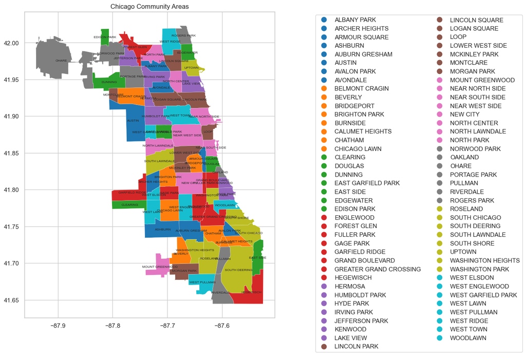

```python
# Create figure and axis
fig, ax = plt.subplots(figsize=(15, 10))

# Plot your GeoDataFrame
chicago = gpd.read_file(r'/Users/gracegormley/Desktop/Stat 303-1/project/Boundaries - Community Areas_20251127/geo_export_a0f75e4e-d093-4b60-9319-7b3e6e34a0ad.shp')
chicago.plot(column='community', ax=ax, legend=True, legend_kwds={'ncol': 2, 'bbox_to_anchor': (2, 1)}, linewidth=0.2)
# Add community labels
for idx, row in chicago.iterrows():
    x = row.geometry.centroid.x
    y = row.geometry.centroid.y
    ax.text(
        x, y,
        row['community'],
        fontsize=6,
        ha='center',
        va='center'
    )

# Add title (optional)
plt.title('Chicago Community Areas');
```

### 1.3.2 Data Preparation and Cleaning

*By Grace Gormley*

#### 1.3.2.1 Assigning neighborhoods to Divvy, Traffic and Bike Stations

```python
#Okay, for this part, I had chat explain the workflow to me, since I am unfamiliar with shapefile objects. Code is copied over and modified for my datasets

    #Step 1 (since we already have shapefile as geospacial object): convert dataframe
from shapely.geometry import Point
gdf_points = gpd.GeoDataFrame(divvy, geometry = gpd.points_from_xy(divvy.start_lng, divvy.start_lat), crs = "EPSG:4326")
```

```python
    #Step 2: Making sure they have same coordinate system
print(chicago.crs)
print(gdf_points.crs)

    #Step 3: Now I assign each row to its neighborhood
divvy_nb = gpd.sjoin(gdf_points, chicago, how="left", predicate="within")
```

```
EPSG:4326
EPSG:4326
```

```python
divvy_nb.head()
#YAYYYY
```

|  | ride_id | rideable_type | started_at | ended_at | start_station_name | start_station_id | end_station_name | end_station_id | start_lat | start_lng | end_lat | end_lng | member_casual | geometry | index_right | area_numbe | community | area_num_1 | shape_area | shape_len |
| --- | --- | --- | --- | --- | --- | --- | --- | --- | --- | --- | --- | --- | --- | --- | --- | --- | --- | --- | --- | --- |
| 3486147 | 6A9D809ABDF70617 | electric_bike | 2024-01-01 00:00:39 | 2024-01-01 00:07:56 | NaN | NaN | Clark St & Wrightwood Ave | TA1305000014 | 41.950000 | -87.650000 | 41.929546 | -87.643118 | member | POINT (-87.65 41.95) | 5.0 | 6.0 | LAKE VIEW | 6 | 8.721480e+07 | 51973.096868 |
| 3491360 | 26B9F6E416A68EBA | electric_bike | 2024-01-01 00:00:50 | 2024-01-01 00:04:20 | NaN | NaN | NaN | NaN | 41.900000 | -87.620000 | 41.900000 | -87.620000 | casual | POINT (-87.62 41.9) | 7.0 | 8.0 | NEAR NORTH SIDE | 8 | 7.667590e+07 | 57293.164952 |
| 3486040 | 30EF016A0DF5ECEE | electric_bike | 2024-01-01 00:00:52 | 2024-01-01 00:04:25 | NaN | NaN | NaN | NaN | 41.900000 | -87.620000 | 41.900000 | -87.620000 | casual | POINT (-87.62 41.9) | 7.0 | 8.0 | NEAR NORTH SIDE | 8 | 7.667590e+07 | 57293.164952 |
| 3467452 | 0D9E85F804C85828 | electric_bike | 2024-01-01 00:00:53 | 2024-01-01 00:22:30 | Clinton St & Madison St | TA1305000032 | NaN | NaN | 41.881909 | -87.641296 | 41.890000 | -87.620000 | member | POINT (-87.6413 41.88191) | 27.0 | 28.0 | NEAR WEST SIDE | 28 | 1.584925e+08 | 53003.592941 |
| 3410785 | 56F5C3ED5178C131 | classic_bike | 2024-01-01 00:01:01 | 2024-01-01 00:24:12 | LaSalle St & Illinois St | 13430 | Indiana Ave & Roosevelt Rd | SL-005 | 41.890762 | -87.631697 | 41.867888 | -87.623041 | member | POINT (-87.6317 41.89076) | 7.0 | 8.0 | NEAR NORTH SIDE | 8 | 7.667590e+07 | 57293.164952 |

```python
#I'll do that with Traffic and bike stations (clean ones)
gdf_points1 = gpd.GeoDataFrame(traffic, geometry = gpd.points_from_xy(traffic['START_LONGITUDE'], traffic[' START_LATITUDE']), crs = "EPSG:4326") #dumb space before lat :\ this took me like 15 minutes to find but oh well :)
traffic = gpd.sjoin(gdf_points1, chicago, how="left", predicate="within")
```

```python
gdf_points4 = gpd.GeoDataFrame(bike_stations, geometry = gpd.points_from_xy(bike_stations['Longitude'], bike_stations['Latitude']), crs = "EPSG:4326")
bike_stations = gpd.sjoin(gdf_points4, chicago, how="left", predicate="within")
```

#### 1.3.2.2 Cleaning Traffic

```python
traffic.head()
traffic.isnull().sum() #some missing community values... going to try to find where those are
```

```
SEGMENTID             0
STREET                0
DIRECTION             0
FROM_STREET           0
TO_STREET             0
LENGTH                0
 STREET_HEADING       0
 COMMENTS          1032
START_LONGITUDE       0
 START_LATITUDE       0
END_LONGITUDE         0
 END_LATITUDE         0
 CURRENT_SPEED        0
 LAST_UPDATED         0
geometry              0
index_right         159
area_numbe          159
community           159
area_num_1          159
shape_area          159
shape_len           159
dtype: int64
```

Visually looking for where the missing community values are:

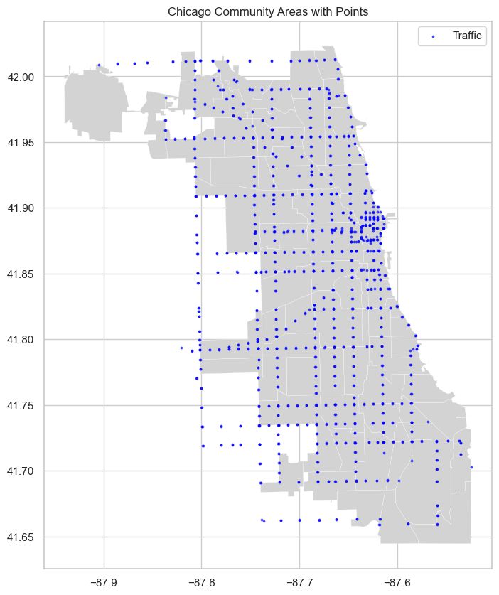

```python
fig, ax = plt.subplots(figsize=(15, 10))

chicago.plot(column='community', ax=ax, color='lightgray',    # light neutral background
    edgecolor='white', legend=False,
             legend_kwds={'ncol': 2, 'bbox_to_anchor': (2, 1)},linewidth=0.2)

gdf_points1.plot(ax=ax, color='blue', markersize=3, alpha=0.6, label='Traffic')

plt.legend()
plt.title('Chicago Community Areas with Points')
```

```python
# using geopandas 'within' function!
inside = gdf_points1.within(chicago.unary_union)
outside_count = (~inside).sum()

print(f"Points outside Chicago boundaries: {outside_count}")
```

```
Points outside Chicago boundaries: 159
```

Great, it seems the values here that are missing a neighborhood are the ones outside of the neighborhood limit. I’ll remove them, since I am going to analyze based on chicago neighborhood.

```python
traffic = traffic.dropna(subset=['community'])
traffic.isnull().sum()
#that cleans it up
```

```
SEGMENTID             0
STREET                0
DIRECTION             0
FROM_STREET           0
TO_STREET             0
LENGTH                0
 STREET_HEADING       0
 COMMENTS          1007
START_LONGITUDE       0
 START_LATITUDE       0
END_LONGITUDE         0
 END_LATITUDE         0
 CURRENT_SPEED        0
 LAST_UPDATED         0
geometry              0
index_right           0
area_numbe            0
community             0
area_num_1            0
shape_area            0
shape_len             0
dtype: int64
```

#### 1.3.2.3 Preparing/Cleaning Bus Stops and L Stops

```python
#splitting bus stops and L stops into two coords (right now they have columns like "coordinates" and I need two)
    #bus stops
bus_stops["coords_clean"] = (
    bus_stops["the_geom"]
    .str.replace("POINT (", "", regex=False)
    .str.replace(")", "", regex=False)
)
bus_stops[["LON", "LAT"]] = bus_stops["coords_clean"].str.split(" ", expand=True)
bus_stops["LON"] = bus_stops["LON"].astype(float)
bus_stops["LAT"] = bus_stops["LAT"].astype(float)

gdf_points2 = gpd.GeoDataFrame(bus_stops, geometry = gpd.points_from_xy(bus_stops['LON'], bus_stops['LAT']), crs = "EPSG:4326")
bus_stops = gpd.sjoin(gdf_points2, chicago, how="left", predicate="within")
```

```python
    #L stops
L_stops["coords_clean"] = (
    L_stops["Location"]
    .str.replace("(", "", regex=False)
    .str.replace(")", "", regex=False)
)
L_stops[["LAT", "LON"]] = L_stops["coords_clean"].str.split(",", expand=True)
L_stops["LON"] = L_stops["LON"].astype(float)
L_stops["LAT"] = L_stops["LAT"].astype(float)

gdf_points3 = gpd.GeoDataFrame(L_stops, geometry = gpd.points_from_xy(L_stops['LON'], L_stops['LAT']), crs = "EPSG:4326")
L_stops = gpd.sjoin(gdf_points3, chicago, how="left", predicate="within")
L_stops.head()
```

|  | STOP_ID | DIRECTION_ID | STOP_NAME | STATION_NAME | STATION_DESCRIPTIVE_NAME | MAP_ID | ADA | RED | BLUE | G | ... | coords_clean | LAT | LON | geometry | index_right | area_numbe | community | area_num_1 | shape_area | shape_len |
| --- | --- | --- | --- | --- | --- | --- | --- | --- | --- | --- | --- | --- | --- | --- | --- | --- | --- | --- | --- | --- | --- |
| 0 | 30162 | W | 18th (54th/Cermak-bound) | 18th | 18th (Pink Line) | 40830 | True | False | False | False | ... | 41.857908, -87.669147 | 41.857908 | -87.669147 | POINT (-87.66915 41.85791) | 30.0 | 31.0 | LOWER WEST SIDE | 31 | 8.155072e+07 | 43229.372704 |
| 1 | 30161 | E | 18th (Loop-bound) | 18th | 18th (Pink Line) | 40830 | True | False | False | False | ... | 41.857908, -87.669147 | 41.857908 | -87.669147 | POINT (-87.66915 41.85791) | 30.0 | 31.0 | LOWER WEST SIDE | 31 | 8.155072e+07 | 43229.372704 |
| 2 | 30022 | N | 35th/Archer (Loop-bound) | 35th/Archer | 35th/Archer (Orange Line) | 40120 | True | False | False | False | ... | 41.829353, -87.680622 | 41.829353 | -87.680622 | POINT (-87.68062 41.82935) | 58.0 | 59.0 | MCKINLEY PARK | 59 | 3.943180e+07 | 26014.096837 |
| 3 | 30023 | S | 35th/Archer (Midway-bound) | 35th/Archer | 35th/Archer (Orange Line) | 40120 | True | False | False | False | ... | 41.829353, -87.680622 | 41.829353 | -87.680622 | POINT (-87.68062 41.82935) | 58.0 | 59.0 | MCKINLEY PARK | 59 | 3.943180e+07 | 26014.096837 |
| 4 | 30213 | N | 35-Bronzeville-IIT (Harlem-bound) | 35th-Bronzeville-IIT | 35th-Bronzeville-IIT (Green Line) | 41120 | True | False | False | True | ... | 41.831677, -87.625826 | 41.831677 | -87.625826 | POINT (-87.62583 41.83168) | 34.0 | 35.0 | DOUGLAS | 35 | 4.600462e+07 | 31027.054510 |

5 rows × 26 columns

#### 1.3.2.4 Visualizing the physical distribution of variables by neighborhood

(I went back to this graph a lot during my analysis, commenting out the irrelevant data so it’s not too crowded. I know it’s tough to read now, it was more for reference for me.)

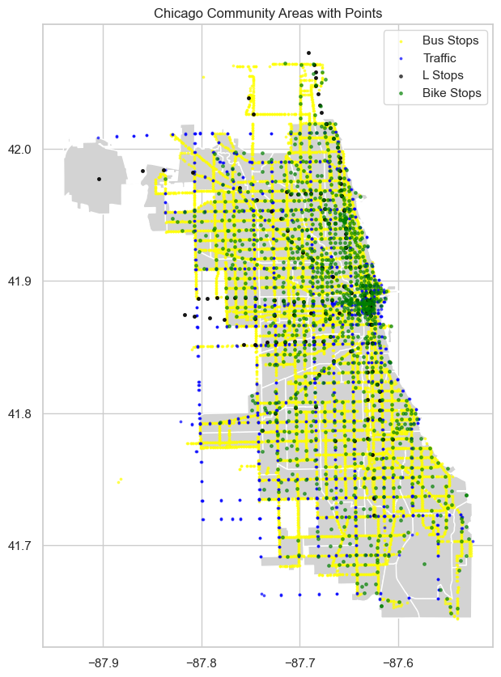

```python
fig, ax = plt.subplots(figsize=(15, 10))

chicago.plot(column='community', ax=ax, color='lightgray',    # light neutral background
    edgecolor='white', legend=False,
             legend_kwds={'ncol': 2, 'bbox_to_anchor': (2, 1)})

gdf_points2.plot(ax=ax, color='yellow', markersize=3, alpha=0.6, label='Bus Stops')
gdf_points1.plot(ax=ax, color='blue', markersize=3, alpha=0.6, label='Traffic')
gdf_points3.plot(ax=ax, color='black', markersize=6, alpha=0.6, label='L Stops')
gdf_points4.plot(ax=ax, color='green', markersize=6, alpha=0.6, label='Bike Stops')


#gdf_points.plot(ax=ax, color='blue', markersize=10, alpha=0.6, label='divvy_ride_start') this shows the divvy points and takes about 1 million years to load

plt.legend()
plt.title('Chicago Community Areas with Points')
```

#### 1.3.2.5 Cleaning/Prepping Traffic and Population

```python
#for traffic: A value of -1 means no estimate is available, according to the documentation, so I'll clean them up and get rid of them
traffic_cleaned = traffic[traffic[' CURRENT_SPEED'] != -1]

traffic_cleaned_neighb = traffic_cleaned.groupby(['community'])[' CURRENT_SPEED'].agg(['mean'])
traffic_cleaned_neighb.reset_index(inplace=True)
traffic_cleaned_neighb = traffic_cleaned_neighb.rename(columns={'mean':'avg_traffic_speed'})

traffic_cleaned_neighb #this I will append to whatever finished product I have
```

|  | community | avg_traffic_speed |
| --- | --- | --- |
| 0 | ALBANY PARK | 22.333333 |
| 1 | ARCHER HEIGHTS | 23.555556 |
| 2 | ARMOUR SQUARE | 23.750000 |
| 3 | ASHBURN | 25.304348 |
| 4 | AUBURN GRESHAM | 23.107143 |
| ... | ... | ... |
| 69 | WEST LAWN | 24.888889 |
| 70 | WEST PULLMAN | 32.333333 |
| 71 | WEST RIDGE | 22.285714 |
| 72 | WEST TOWN | 21.421053 |
| 73 | WOODLAWN | 21.166667 |

74 rows × 2 columns

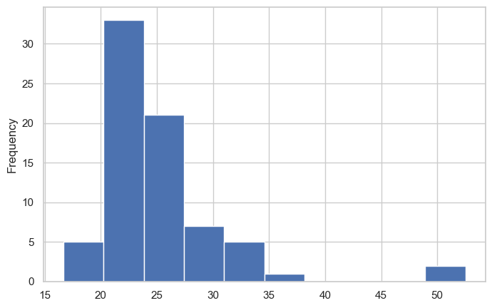

```python
traffic_cleaned_neighb.avg_traffic_speed.plot.hist() #making sure the traffic isn't all too similar for analysis. It looks like it has some interesting distribution.
```

```python
#cleaning population (removing 2023) - I'm removing 2023 since my divvy data is 2024-2025 only
population['ACS Year'] = pd.to_datetime(population['ACS Year'], errors='coerce')
population = population[population['ACS Year'].dt.year != 2023]

#finding avg pop per neighborhood (since divvy data is 2024-2025, I'll average populations)
population_avg = population.groupby(['Community Area'])['Total Population'].agg(['mean'])
population_avg.reset_index(inplace=True)
population_avg = population_avg.rename(columns={'Community Area': 'community', 'mean':'population_avg'})
population_avg #yay! this is good for my per capita table!
```

|  | community | population_avg |
| --- | --- | --- |
| 0 | ALBANY PARK | 47830.0 |
| 1 | ARCHER HEIGHTS | 13875.0 |
| 2 | ARMOUR SQUARE | 13149.0 |
| 3 | ASHBURN | 42842.0 |
| 4 | AUBURN GRESHAM | 46483.0 |
| ... | ... | ... |
| 72 | WEST LAWN | 32451.0 |
| 73 | WEST PULLMAN | 25159.0 |
| 74 | WEST RIDGE | 79220.0 |
| 75 | WEST TOWN | 86453.0 |
| 76 | WOODLAWN | 24437.0 |

77 rows × 2 columns

#### 1.3.2.6 Final Prep of Each Dataframe before Joining

Okay, at this point, I could make a table with population, mean traffic. I need to organize # of L stops, # of divvy stops, # of bus stops by neighborhood. Finally then I will add the divvy data and per capita data, and deal with the messes there.

```python
num_L_stops = (L_stops.groupby('community')['MAP_ID'].nunique().reset_index().rename(columns={'MAP_ID': 'num_L_stops'}))

num_bus_stops = (bus_stops.groupby('community')['SYSTEMSTOP'].nunique().reset_index().rename(columns={'SYSTEMSTOP': 'num_bus_stops'}))

num_bike_stops = (bike_stations.groupby('community')['ID'].nunique().reset_index().rename(columns={'ID': 'num_bike_stops'}))

num_L_stops.head()
```

|  | community | num_L_stops |
| --- | --- | --- |
| 0 | ALBANY PARK | 3 |
| 1 | ARMOUR SQUARE | 2 |
| 2 | AUSTIN | 5 |
| 3 | AVONDALE | 1 |
| 4 | BRIDGEPORT | 1 |

```python
num_bike_stops.head()
```

|  | community | num_bike_stops |
| --- | --- | --- |
| 0 | ALBANY PARK | 8 |
| 1 | ARCHER HEIGHTS | 9 |
| 2 | ARMOUR SQUARE | 9 |
| 3 | ASHBURN | 13 |
| 4 | AUBURN GRESHAM | 11 |

```python
num_L_stops.head()
```

|  | community | num_L_stops |
| --- | --- | --- |
| 0 | ALBANY PARK | 3 |
| 1 | ARMOUR SQUARE | 2 |
| 2 | AUSTIN | 5 |
| 3 | AVONDALE | 1 |
| 4 | BRIDGEPORT | 1 |

```python
divvy_nb_count = (divvy_nb.groupby('community')['ride_id'].nunique().reset_index().rename(columns={'ride_id': 'num_divvy_rides'}))
divvy_nb_count.head()
```

|  | community | num_divvy_rides |
| --- | --- | --- |
| 0 | ALBANY PARK | 25540 |
| 1 | ARCHER HEIGHTS | 3470 |
| 2 | ARMOUR SQUARE | 65029 |
| 3 | ASHBURN | 2263 |
| 4 | AUBURN GRESHAM | 3112 |

Okay! I think everything is ready to concatenate my first comparison dataset!

### 1.3.3 Making the dataset

```python
merged = population_avg \
    .merge(num_L_stops, on='community', how='left') \
    .merge(num_bus_stops, on='community', how='left') \
    .merge(num_bike_stops, on='community', how='left') \
    .merge(divvy_nb_count, on='community', how = 'left') \
    .merge(traffic_cleaned_neighb, on='community', how='left')

merged
```

|  | community | population_avg | num_L_stops | num_bus_stops | num_bike_stops | num_divvy_rides | avg_traffic_speed |
| --- | --- | --- | --- | --- | --- | --- | --- |
| 0 | ALBANY PARK | 47830.0 | 3.0 | 91 | 8.0 | 25540 | 22.333333 |
| 1 | ARCHER HEIGHTS | 13875.0 | NaN | 66 | 9.0 | 3470 | 23.555556 |
| 2 | ARMOUR SQUARE | 13149.0 | 2.0 | 60 | 9.0 | 65029 | 23.750000 |
| 3 | ASHBURN | 42842.0 | NaN | 131 | 13.0 | 2263 | 25.304348 |
| 4 | AUBURN GRESHAM | 46483.0 | NaN | 172 | 11.0 | 3112 | 23.107143 |
| ... | ... | ... | ... | ... | ... | ... | ... |
| 72 | WEST LAWN | 32451.0 | NaN | 79 | 10.0 | 2556 | 24.888889 |
| 73 | WEST PULLMAN | 25159.0 | NaN | 104 | 11.0 | 1153 | 32.333333 |
| 74 | WEST RIDGE | 79220.0 | NaN | 195 | 21.0 | 35596 | 22.285714 |
| 75 | WEST TOWN | 86453.0 | 4.0 | 287 | 56.0 | 778781 | 21.421053 |
| 76 | WOODLAWN | 24437.0 | 2.0 | 146 | 13.0 | 70705 | 21.166667 |

77 rows × 7 columns

```python
#this is the per capita ones

merged['L_stops_per_capita'] = merged['num_L_stops'] / merged['population_avg']
merged['bus_stops_per_capita'] = merged['num_bus_stops'] / merged['population_avg']
merged['bike_stops_per_capita'] = merged['num_bike_stops'] / merged['population_avg']
merged['divvy_per_capita'] = merged['num_divvy_rides'] / merged['population_avg']

merged
```

|  | community | population_avg | num_L_stops | num_bus_stops | num_bike_stops | num_divvy_rides | avg_traffic_speed | L_stops_per_capita | bus_stops_per_capita | bike_stops_per_capita | divvy_per_capita |
| --- | --- | --- | --- | --- | --- | --- | --- | --- | --- | --- | --- |
| 0 | ALBANY PARK | 47830.0 | 3.0 | 91 | 8.0 | 25540 | 22.333333 | 0.000063 | 0.001903 | 0.000167 | 0.533974 |
| 1 | ARCHER HEIGHTS | 13875.0 | NaN | 66 | 9.0 | 3470 | 23.555556 | NaN | 0.004757 | 0.000649 | 0.250090 |
| 2 | ARMOUR SQUARE | 13149.0 | 2.0 | 60 | 9.0 | 65029 | 23.750000 | 0.000152 | 0.004563 | 0.000684 | 4.945547 |
| 3 | ASHBURN | 42842.0 | NaN | 131 | 13.0 | 2263 | 25.304348 | NaN | 0.003058 | 0.000303 | 0.052822 |
| 4 | AUBURN GRESHAM | 46483.0 | NaN | 172 | 11.0 | 3112 | 23.107143 | NaN | 0.003700 | 0.000237 | 0.066949 |
| ... | ... | ... | ... | ... | ... | ... | ... | ... | ... | ... | ... |
| 72 | WEST LAWN | 32451.0 | NaN | 79 | 10.0 | 2556 | 24.888889 | NaN | 0.002434 | 0.000308 | 0.078765 |
| 73 | WEST PULLMAN | 25159.0 | NaN | 104 | 11.0 | 1153 | 32.333333 | NaN | 0.004134 | 0.000437 | 0.045829 |
| 74 | WEST RIDGE | 79220.0 | NaN | 195 | 21.0 | 35596 | 22.285714 | NaN | 0.002461 | 0.000265 | 0.449331 |
| 75 | WEST TOWN | 86453.0 | 4.0 | 287 | 56.0 | 778781 | 21.421053 | 0.000046 | 0.003320 | 0.000648 | 9.008143 |
| 76 | WOODLAWN | 24437.0 | 2.0 | 146 | 13.0 | 70705 | 21.166667 | 0.000082 | 0.005975 | 0.000532 | 2.893358 |

77 rows × 11 columns

#### 1.3.3.1 Adding a population density metric

```python
chicago_proj = chicago.to_crs(epsg=3435)  # Illinois State Plane in meters (got this conversion line from AI after the first time didn't work)

chicago_proj['area_sqm'] = chicago_proj.geometry.area

chicago_proj['area_km2'] = chicago_proj['area_sqm'] / 1e6 #convert to km

neighborhood_areas = chicago_proj[['community', 'area_km2']]
print(neighborhood_areas)
```

```
             community    area_km2
0          ROGERS PARK   51.259902
1           WEST RIDGE   98.429095
2               UPTOWN   65.095643
3       LINCOLN SQUARE   71.352328
4         NORTH CENTER   57.054168
..                 ...         ...
72  WASHINGTON HEIGHTS   79.635753
73     MOUNT GREENWOOD   75.584290
74         MORGAN PARK   91.877341
75               OHARE  371.835608
76           EDGEWATER   48.449991

[77 rows x 2 columns]
```

```python
merged = merged \
    .merge(neighborhood_areas, on='community', how='left')

merged['pop_density'] = merged['population_avg']/merged['area_km2']
merged
```

|  | community | population_avg | num_L_stops | num_bus_stops | num_bike_stops | num_divvy_rides | avg_traffic_speed | L_stops_per_capita | bus_stops_per_capita | bike_stops_per_capita | divvy_per_capita | area_km2 | pop_density |
| --- | --- | --- | --- | --- | --- | --- | --- | --- | --- | --- | --- | --- | --- |
| 0 | ALBANY PARK | 47830.0 | 3.0 | 91 | 8.0 | 25540 | 22.333333 | 0.000063 | 0.001903 | 0.000167 | 0.533974 | 53.542231 | 893.313545 |
| 1 | ARCHER HEIGHTS | 13875.0 | NaN | 66 | 9.0 | 3470 | 23.555556 | NaN | 0.004757 | 0.000649 | 0.250090 | 55.922506 | 248.111200 |
| 2 | ARMOUR SQUARE | 13149.0 | 2.0 | 60 | 9.0 | 65029 | 23.750000 | 0.000152 | 0.004563 | 0.000684 | 4.945547 | 27.766196 | 473.561447 |
| 3 | ASHBURN | 42842.0 | NaN | 131 | 13.0 | 2263 | 25.304348 | NaN | 0.003058 | 0.000303 | 0.052822 | 135.460337 | 316.269699 |
| 4 | AUBURN GRESHAM | 46483.0 | NaN | 172 | 11.0 | 3112 | 23.107143 | NaN | 0.003700 | 0.000237 | 0.066949 | 105.065354 | 442.419869 |
| ... | ... | ... | ... | ... | ... | ... | ... | ... | ... | ... | ... | ... | ... |
| 72 | WEST LAWN | 32451.0 | NaN | 79 | 10.0 | 2556 | 24.888889 | NaN | 0.002434 | 0.000308 | 0.078765 | 82.315302 | 394.228040 |
| 73 | WEST PULLMAN | 25159.0 | NaN | 104 | 11.0 | 1153 | 32.333333 | NaN | 0.004134 | 0.000437 | 0.045829 | 99.365198 | 253.197301 |
| 74 | WEST RIDGE | 79220.0 | NaN | 195 | 21.0 | 35596 | 22.285714 | NaN | 0.002461 | 0.000265 | 0.449331 | 98.429095 | 804.843325 |
| 75 | WEST TOWN | 86453.0 | 4.0 | 287 | 56.0 | 778781 | 21.421053 | 0.000046 | 0.003320 | 0.000648 | 9.008143 | 127.562905 | 677.728375 |
| 76 | WOODLAWN | 24437.0 | 2.0 | 146 | 13.0 | 70705 | 21.166667 | 0.000082 | 0.005975 | 0.000532 | 2.893358 | 57.815180 | 422.674464 |

77 rows × 13 columns

#### 1.3.3.2 Cleaning the Merged Dataset

```python
merged.isnull().sum()
```

```
community                 0
population_avg            0
num_L_stops              35
num_bus_stops             0
num_bike_stops            3
num_divvy_rides           0
avg_traffic_speed         3
L_stops_per_capita       35
bus_stops_per_capita      0
bike_stops_per_capita     3
divvy_per_capita          0
area_km2                  0
pop_density               0
dtype: int64
```

surprisingly very few null values here…. i know the row would be n/an if there’s a zero for the rows where I applied the value_counts funtion (since that’s how value_counts deal with 0s), which is L_stops and bike_stops. Let’s double check that.

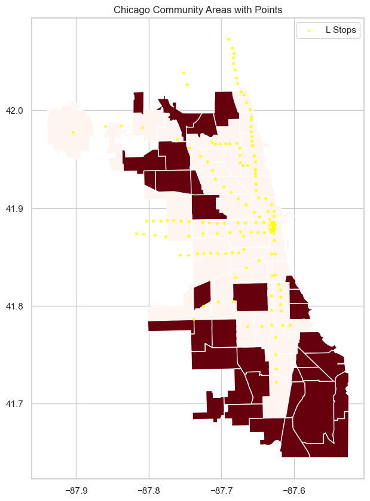

```python
#printing the neighborhoods with null L stops
no_L = merged.loc[merged['num_L_stops'].isna(), 'community'].unique()


#trying to see graphically - this should highlight red the null communities and also print the L stops, so I can see if there is overlap (if i'm right there should be none)
fig, ax = plt.subplots(figsize=(15, 10))

chicago['highlight'] = chicago['community'].isin(no_L)

chicago.plot(column='highlight', ax=ax, cmap='Reds', edgecolor='white', legend=False)

gdf_points3.plot(ax=ax, color='yellow', markersize=6, alpha=0.6, label='L Stops') #trying yellow since it'll show up well on the dark red maybe

plt.legend()
plt.title('Chicago Community Areas with Points')
```

Yay! There is no yellow in ay of the red boxes, so it looks like for L stops, a null value means zero. Let’s check bike stops.

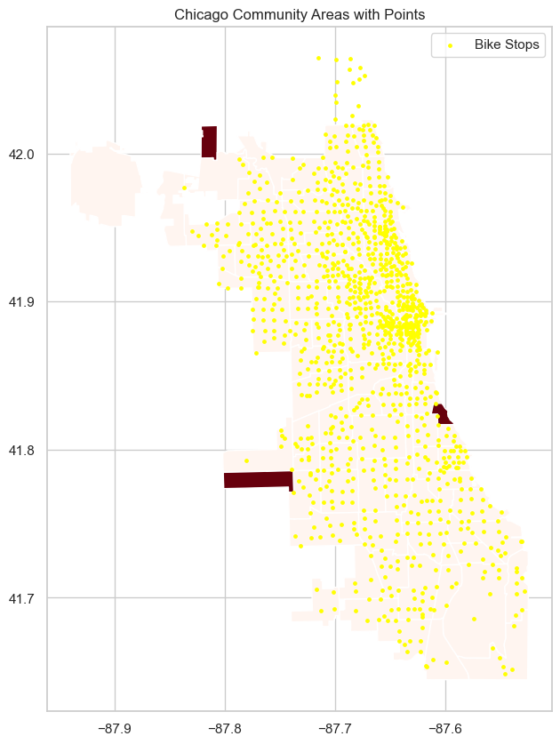

```python
#printing the neighborhoods with null L stops
no_bike = merged.loc[merged['num_bike_stops'].isna(), 'community'].unique()


#trying to see graphically (same code)
fig, ax = plt.subplots(figsize=(15, 10))

chicago['highlight2'] = chicago['community'].isin(no_bike)

chicago.plot(column='highlight2', ax=ax, cmap='Reds', edgecolor='white', legend=False)

gdf_points4.plot(ax=ax, color='yellow', markersize=6, alpha=1, label='Bike Stops')

plt.legend()
plt.title('Chicago Community Areas with Points')
```

Looks like the same for bike stops. N/A means zero. Let’s impute those.

```python
cols_to_impute = ['num_L_stops', 'num_bike_stops', 'L_stops_per_capita', 'bike_stops_per_capita']
merged[cols_to_impute] = merged[cols_to_impute].fillna(0)
merged.isna().sum()
```

```
community                0
population_avg           0
num_L_stops              0
num_bus_stops            0
num_bike_stops           0
num_divvy_rides          0
avg_traffic_speed        3
L_stops_per_capita       0
bus_stops_per_capita     0
bike_stops_per_capita    0
divvy_per_capita         0
area_km2                 0
pop_density              0
dtype: int64
```

Now let’s look into the null traffic speed.

```python
merged[merged.isna().any(axis=1)]
```

|  | community | population_avg | num_L_stops | num_bus_stops | num_bike_stops | num_divvy_rides | avg_traffic_speed | L_stops_per_capita | bus_stops_per_capita | bike_stops_per_capita | divvy_per_capita | area_km2 | pop_density |
| --- | --- | --- | --- | --- | --- | --- | --- | --- | --- | --- | --- | --- | --- |
| 19 | EAST GARFIELD PARK | 19855.0 | 4.0 | 136 | 14.0 | 9877 | NaN | 0.000201 | 0.006850 | 0.000705 | 0.497457 | 53.883221 | 368.482056 |
| 30 | HEGEWISCH | 8895.0 | 0.0 | 47 | 6.0 | 1093 | NaN | 0.000000 | 0.005284 | 0.000675 | 0.122878 | 145.965741 | 60.938957 |
| 62 | SOUTH CHICAGO | 29072.0 | 0.0 | 117 | 10.0 | 3859 | NaN | 0.000000 | 0.004024 | 0.000344 | 0.132739 | 93.272185 | 311.689921 |

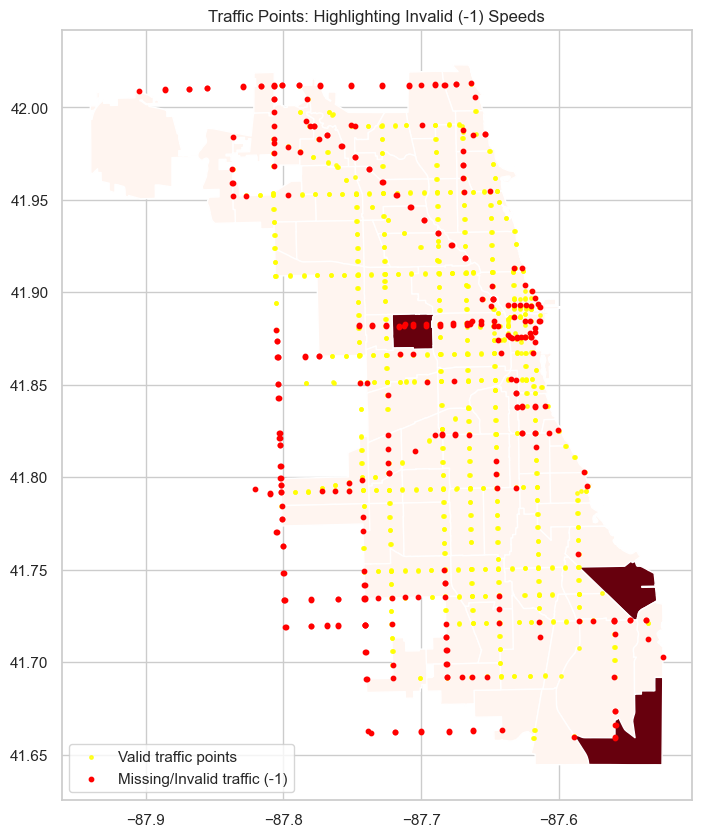

```python
gdf_points_bad = gdf_points1[gdf_points1[' CURRENT_SPEED'] == -1]
gdf_points_good = gdf_points1[gdf_points1[' CURRENT_SPEED'] != -1]

null_traff = merged.loc[merged['avg_traffic_speed'].isna(), 'community'].unique() #mask for the neighborhoods

#same code as above
fig, ax = plt.subplots(figsize=(15, 10))

chicago['highlight3'] = chicago['community'].isin(null_traff)


chicago.plot(column='highlight3', ax=ax, cmap='Reds', edgecolor='white', legend=False)

gdf_points_good.plot(ax=ax, color='yellow', markersize=6, alpha=0.8, label='Valid traffic points') #if there is a yellow in my red blocks, something's wrong. it should be all red if my hunch is right and all the data there is -1

gdf_points_bad.plot(ax=ax, color='red', markersize=10, alpha=1, label='Missing/Invalid traffic (-1)')

plt.legend()
plt.title('Traffic Points: Highlighting Invalid (-1) Speeds');
```

Okay, since there is no yellow in the red polygons, that means the estimated traffic speed in those areas was -1, meaning no estimate was available, and I dropped the value. I don’t want to remove the community, so I’ll just remember those are null for that reason.

### 1.3.4 Data Prep

- I’ve already done some prep, like some standardziation (per capita measurements)
- I think, since I have so many categories (communities) it would benefit me to bin them (for histogram data, etc)

https://en.wikipedia.org/wiki/Community_areas_in_Chicago

https://research.dom.edu/governmentdata/chicago

- These links say that there are established 9 regions (sort of just divided into sides). I’ll bin them in this way. I think maybe the cleanest way to do it is to sum the non-per-capita data, and recalculate per capita stuff.

#### 1.3.4.1 Assigning each neighborhood to a “side”

```python
#making a dictionary to divide into "sides" (I uploaded an image to gemini and had it make the dictionary since it would just be tedious.)

chicago_sides = {
    # FAR NORTH SIDE
    'ROGERS PARK': 'FAR NORTH SIDE',
    'WEST RIDGE': 'FAR NORTH SIDE',
    'UPTOWN': 'FAR NORTH SIDE',
    'LINCOLN SQUARE': 'FAR NORTH SIDE',
    'EDISON PARK': 'FAR NORTH SIDE',
    'NORWOOD PARK': 'FAR NORTH SIDE',
    'JEFFERSON PARK': 'FAR NORTH SIDE',
    'FOREST GLEN': 'FAR NORTH SIDE',
    'NORTH PARK': 'FAR NORTH SIDE',
    'ALBANY PARK': 'FAR NORTH SIDE',
    'EDGEWATER': 'FAR NORTH SIDE',
    "OHARE": 'FAR NORTH SIDE',  # CA 76

    # NORTH SIDE
    'NORTH CENTER': 'NORTH SIDE',
    'LAKE VIEW': 'NORTH SIDE',
    'LINCOLN PARK': 'NORTH SIDE',
    'AVONDALE': 'NORTH SIDE',
    'LOGAN SQUARE': 'NORTH SIDE',

    # NORTH WEST SIDE (Note: Image title is "North West Side", not "Northwest Side")
    'PORTAGE PARK': 'NORTH WEST SIDE',
    'IRVING PARK': 'NORTH WEST SIDE',
    'DUNNING': 'NORTH WEST SIDE',
    'MONTCLARE': 'NORTH WEST SIDE',
    'BELMONT CRAGIN': 'NORTH WEST SIDE',
    'HERMOSA': 'NORTH WEST SIDE',

    # WEST SIDE
    'HUMBOLDT PARK': 'WEST SIDE',
    'WEST TOWN': 'WEST SIDE',
    'AUSTIN': 'WEST SIDE',
    'WEST GARFIELD PARK': 'WEST SIDE',
    'EAST GARFIELD PARK': 'WEST SIDE',
    'NEAR WEST SIDE': 'WEST SIDE',
    'NORTH LAWNDALE': 'WEST SIDE',
    'SOUTH LAWNDALE': 'WEST SIDE',
    'LOWER WEST SIDE': 'WEST SIDE',

    # CENTRAL
    'NEAR NORTH SIDE': 'CENTRAL',
    'LOOP': 'CENTRAL',
    'NEAR SOUTH SIDE': 'CENTRAL',

    # SOUTH SIDE
    'ARMOUR SQUARE': 'SOUTH SIDE',
    'DOUGLAS': 'SOUTH SIDE',
    'OAKLAND': 'SOUTH SIDE',
    'FULLER PARK': 'SOUTH SIDE',
    'GRAND BOULEVARD': 'SOUTH SIDE',
    'KENWOOD': 'SOUTH SIDE',
    'WASHINGTON PARK': 'SOUTH SIDE',
    'HYDE PARK': 'SOUTH SIDE',
    'WOODLAWN': 'SOUTH SIDE',
    'SOUTH SHORE': 'SOUTH SIDE',
    'BRIDGEPORT': 'SOUTH SIDE', # Grouped here in the image's structure
    'GREATER GRAND CROSSING': 'SOUTH SIDE',

    # SOUTHWEST SIDE
    'GARFIELD RIDGE': 'SOUTHWEST SIDE',
    'ARCHER HEIGHTS': 'SOUTHWEST SIDE',
    'BRIGHTON PARK': 'SOUTHWEST SIDE',
    'MCKINLEY PARK': 'SOUTHWEST SIDE',
    'NEW CITY': 'SOUTHWEST SIDE',
    'WEST ELSDON': 'SOUTHWEST SIDE',
    'GAGE PARK': 'SOUTHWEST SIDE',
    'CLEARING': 'SOUTHWEST SIDE',
    'WEST LAWN': 'SOUTHWEST SIDE',
    'CHICAGO LAWN': 'SOUTHWEST SIDE',
    'WEST ENGLEWOOD': 'SOUTHWEST SIDE',
    'ENGLEWOOD': 'SOUTHWEST SIDE',

    # FAR SOUTHWEST SIDE
    'ASHBURN': 'FAR SOUTHWEST SIDE',
    'AUBURN GRESHAM': 'FAR SOUTHWEST SIDE',
    'BEVERLY': 'FAR SOUTHWEST SIDE',
    'WASHINGTON HEIGHTS': 'FAR SOUTHWEST SIDE',
    'MOUNT GREENWOOD': 'FAR SOUTHWEST SIDE',
    'MORGAN PARK': 'FAR SOUTHWEST SIDE',

    # FAR SOUTHEAST SIDE
    'CHATHAM': 'FAR SOUTHEAST SIDE',
    'AVALON PARK': 'FAR SOUTHEAST SIDE',
    'SOUTH CHICAGO': 'FAR SOUTHEAST SIDE',
    'BURNSIDE': 'FAR SOUTHEAST SIDE',
    'CALUMET HEIGHTS': 'FAR SOUTHEAST SIDE',
    'ROSELAND': 'FAR SOUTHEAST SIDE',
    'PULLMAN': 'FAR SOUTHEAST SIDE',
    'SOUTH DEERING': 'FAR SOUTHEAST SIDE',
    'EAST SIDE': 'FAR SOUTHEAST SIDE',
    'WEST PULLMAN': 'FAR SOUTHEAST SIDE',
    'RIVERDALE': 'FAR SOUTHEAST SIDE',
    'HEGEWISCH': 'FAR SOUTHEAST SIDE',
}
```

```python
merged['side'] = merged['community'].map(chicago_sides)

merged.head()
```

|  | community | population_avg | num_L_stops | num_bus_stops | num_bike_stops | num_divvy_rides | avg_traffic_speed | L_stops_per_capita | bus_stops_per_capita | bike_stops_per_capita | divvy_per_capita | area_km2 | pop_density | side |
| --- | --- | --- | --- | --- | --- | --- | --- | --- | --- | --- | --- | --- | --- | --- |
| 0 | ALBANY PARK | 47830.0 | 3.0 | 91 | 8.0 | 25540 | 22.333333 | 0.000063 | 0.001903 | 0.000167 | 0.533974 | 53.542231 | 893.313545 | FAR NORTH SIDE |
| 1 | ARCHER HEIGHTS | 13875.0 | 0.0 | 66 | 9.0 | 3470 | 23.555556 | 0.000000 | 0.004757 | 0.000649 | 0.250090 | 55.922506 | 248.111200 | SOUTHWEST SIDE |
| 2 | ARMOUR SQUARE | 13149.0 | 2.0 | 60 | 9.0 | 65029 | 23.750000 | 0.000152 | 0.004563 | 0.000684 | 4.945547 | 27.766196 | 473.561447 | SOUTH SIDE |
| 3 | ASHBURN | 42842.0 | 0.0 | 131 | 13.0 | 2263 | 25.304348 | 0.000000 | 0.003058 | 0.000303 | 0.052822 | 135.460337 | 316.269699 | FAR SOUTHWEST SIDE |
| 4 | AUBURN GRESHAM | 46483.0 | 0.0 | 172 | 11.0 | 3112 | 23.107143 | 0.000000 | 0.003700 | 0.000237 | 0.066949 | 105.065354 | 442.419869 | FAR SOUTHWEST SIDE |

I want to visualize them to make sure I’m not missing any neighborhoods

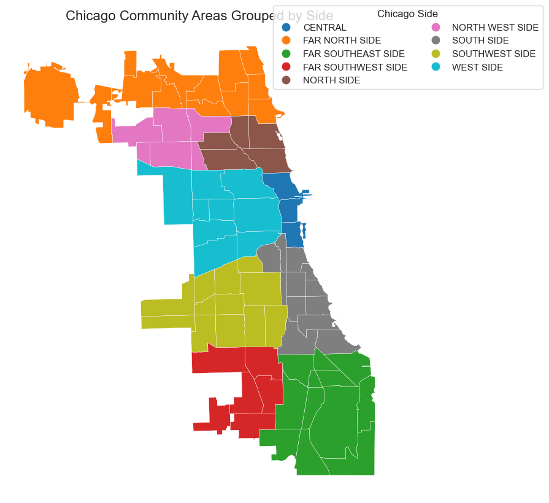

```python
chicago['side'] = chicago['community'].map(chicago_sides) #mapping sides to the communties so I can graph to see the sections

fig, ax = plt.subplots(figsize=(15, 10))

chicago.plot(
    column='side',
    ax=ax,
    legend=True,
    cmap='tab10',  # Using a good categorical colormap
    legend_kwds={'ncol': 2, 'bbox_to_anchor': (1.4, 1.05), 'title': 'Chicago Side'}, linewidth=0.2
)

#gdf_points4.plot(ax=ax, color='white', markersize=6, alpha=0.6, label='Bike Stops')

chicago.boundary.plot(ax=ax, linewidth=0.1, color='white')
ax.set_axis_off()

plt.title('Chicago Community Areas Grouped by Side', fontsize=16)
plt.show()
```

```python
#Initially we were missing ohare and the loop so I added those. (Loop was called "the Loop" in dictonary and ohare was called "O'hare"). It looks good after fixing that.
```

#### 1.3.4.2 Making a binned dataset

Now that I have added the “sides” bins, I need to make a new dataframe with the combined information.

```python
side_data = merged.groupby('side').agg(
    #sums for not per-capita-data (CAREFUL TO GET SAME ORDER FOR CORRELATION MATRIX GRAPH LATER)

    Total_Population=('population_avg', 'sum'),
    Total_L_Stops=('num_L_stops', 'sum'),
    Total_Bus_Stops=('num_bus_stops', 'sum'),
    Total_Divvy_Stations=('num_bike_stops', 'sum'),
    Total_Divvy_Rides=('num_divvy_rides', 'sum')
)
side_data.head()
```

| side | Total_Population | Total_L_Stops | Total_Bus_Stops | Total_Divvy_Stations | Total_Divvy_Rides |
| --- | --- | --- | --- | --- | --- |
| CENTRAL | 156226.0 | 25.0 | 493 | 134.0 | 3734447 |
| FAR NORTH SIDE | 456323.0 | 22.0 | 1241 | 119.0 | 878282 |
| FAR SOUTHEAST SIDE | 209345.0 | 3.0 | 1046 | 92.0 | 20394 |
| FAR SOUTHWEST SIDE | 175841.0 | 0.0 | 656 | 50.0 | 12637 |
| NORTH SIDE | 296205.0 | 15.0 | 844 | 178.0 | 2968640 |

```python
# I need the original traffic dataset (with community) to get good averages. If I average
# based on merged, then each neighborhood has equal weight, and I think it will be more accurate if I go from the start,
# where each route is weighted equally

traffic['side'] = traffic['community'].map(chicago_sides) #adding "side"
traffic_cleaned2 = traffic[traffic[' CURRENT_SPEED'] != -1] #getting rid of -1s (no data)

#same process as I did above to get the avg by community.
traffic_cleaned_side = traffic_cleaned2.groupby(['side'])[' CURRENT_SPEED'].agg(['mean'])
traffic_cleaned_side.reset_index(inplace=True)
traffic_cleaned_side = traffic_cleaned_side.rename(columns={'mean':'avg_traffic_speed_side'})

traffic_cleaned_side.head()
#okay this looks good. I'll join with the one above^
```

|  | side | avg_traffic_speed_side |
| --- | --- | --- |
| 0 | CENTRAL | 22.500000 |
| 1 | FAR NORTH SIDE | 24.725000 |
| 2 | FAR SOUTHEAST SIDE | 26.623188 |
| 3 | FAR SOUTHWEST SIDE | 24.487500 |
| 4 | NORTH SIDE | 23.917808 |

```python
side_data = side_data \
    .merge(traffic_cleaned_side, on=['side'], how='left')

side_data
```

|  | side | Total_Population | Total_L_Stops | Total_Bus_Stops | Total_Divvy_Stations | Total_Divvy_Rides | avg_traffic_speed_side |
| --- | --- | --- | --- | --- | --- | --- | --- |
| 0 | CENTRAL | 156226.0 | 25.0 | 493 | 134.0 | 3734447 | 22.500000 |
| 1 | FAR NORTH SIDE | 456323.0 | 22.0 | 1241 | 119.0 | 878282 | 24.725000 |
| 2 | FAR SOUTHEAST SIDE | 209345.0 | 3.0 | 1046 | 92.0 | 20394 | 26.623188 |
| 3 | FAR SOUTHWEST SIDE | 175841.0 | 0.0 | 656 | 50.0 | 12637 | 24.487500 |
| 4 | NORTH SIDE | 296205.0 | 15.0 | 844 | 178.0 | 2968640 | 23.917808 |
| 5 | NORTH WEST SIDE | 271227.0 | 3.0 | 898 | 89.0 | 119101 | 22.896552 |
| 6 | SOUTH SIDE | 246744.0 | 14.0 | 1295 | 114.0 | 709917 | 27.386667 |
| 7 | SOUTHWEST SIDE | 358308.0 | 8.0 | 1472 | 111.0 | 48670 | 24.884058 |
| 8 | WEST SIDE | 477402.0 | 34.0 | 1983 | 250.0 | 2244765 | 22.100000 |

```python
#Now I need the per capita. I'll reuse my code.
side_data['L_stops_per_capita'] = side_data['Total_L_Stops'] / side_data['Total_Population']
side_data['bus_stops_per_capita'] = side_data['Total_Bus_Stops'] / side_data['Total_Population']
side_data['bike_stops_per_capita'] = side_data['Total_Divvy_Stations'] / side_data['Total_Population']
side_data['divvy_per_capita'] = side_data['Total_Divvy_Rides'] / side_data['Total_Population']

side_data
```

|  | side | Total_Population | Total_L_Stops | Total_Bus_Stops | Total_Divvy_Stations | Total_Divvy_Rides | avg_traffic_speed_side | L_stops_per_capita | bus_stops_per_capita | bike_stops_per_capita | divvy_per_capita |
| --- | --- | --- | --- | --- | --- | --- | --- | --- | --- | --- | --- |
| 0 | CENTRAL | 156226.0 | 25.0 | 493 | 134.0 | 3734447 | 22.500000 | 0.000160 | 0.003156 | 0.000858 | 23.904132 |
| 1 | FAR NORTH SIDE | 456323.0 | 22.0 | 1241 | 119.0 | 878282 | 24.725000 | 0.000048 | 0.002720 | 0.000261 | 1.924694 |
| 2 | FAR SOUTHEAST SIDE | 209345.0 | 3.0 | 1046 | 92.0 | 20394 | 26.623188 | 0.000014 | 0.004997 | 0.000439 | 0.097418 |
| 3 | FAR SOUTHWEST SIDE | 175841.0 | 0.0 | 656 | 50.0 | 12637 | 24.487500 | 0.000000 | 0.003731 | 0.000284 | 0.071866 |
| 4 | NORTH SIDE | 296205.0 | 15.0 | 844 | 178.0 | 2968640 | 23.917808 | 0.000051 | 0.002849 | 0.000601 | 10.022248 |
| 5 | NORTH WEST SIDE | 271227.0 | 3.0 | 898 | 89.0 | 119101 | 22.896552 | 0.000011 | 0.003311 | 0.000328 | 0.439119 |
| 6 | SOUTH SIDE | 246744.0 | 14.0 | 1295 | 114.0 | 709917 | 27.386667 | 0.000057 | 0.005248 | 0.000462 | 2.877140 |
| 7 | SOUTHWEST SIDE | 358308.0 | 8.0 | 1472 | 111.0 | 48670 | 24.884058 | 0.000022 | 0.004108 | 0.000310 | 0.135833 |
| 8 | WEST SIDE | 477402.0 | 34.0 | 1983 | 250.0 | 2244765 | 22.100000 | 0.000071 | 0.004154 | 0.000524 | 4.702044 |

```python
side_data.isnull().sum()
```

```
side                      0
Total_Population          0
Total_L_Stops             0
Total_Bus_Stops           0
Total_Divvy_Stations      0
Total_Divvy_Rides         0
avg_traffic_speed_side    0
L_stops_per_capita        0
bus_stops_per_capita      0
bike_stops_per_capita     0
divvy_per_capita          0
dtype: int64
```

Great, this is my binned dataset.

# 2 Data Analysis

## 2.1 Jenna’s Analysis

### 2.1.1 Distribution of Socioeconomic Status

*By Jenna Krinsky*

```python
income_cols = [
    'Under $25,000',
    '$25,000 to $49,999',
    '$50,000 to $74,999',
    '$75,000 to $125,000',
    '$125,000 +',
    'Total Population'
]

# Remove commas and convert to numeric (used AI for help with converting in an efficienct way)
for col in income_cols:
    chicago_dem[col] = (
        chicago_dem[col]
        .astype(str)
        .str.replace(',', '', regex=True)
        .astype(float)
    )
```

```python
#finding percentages for each income bin to make socioeconomic status graphs

pop = chicago_dem['Under $25,000'] + chicago_dem['$25,000 to $49,999'] + chicago_dem['$50,000 to $74,999'] + chicago_dem['$75,000 to $125,000'] + chicago_dem['$125,000 +']

#divide by total people who report their income NOT the total population because there would be different percentages of responses for each community
chicago_dem['pct_under_25k'] = chicago_dem['Under $25,000'] / (pop) * 100
chicago_dem['pct_25_49k']   = chicago_dem['$25,000 to $49,999'] / (pop) * 100
chicago_dem['pct_50_74k']   = chicago_dem['$50,000 to $74,999'] / (pop) * 100
chicago_dem['pct_75_125k']  = chicago_dem['$75,000 to $125,000'] / (pop) * 100
chicago_dem['pct_125_plus'] = chicago_dem['$125,000 +'] / (pop) * 100
```

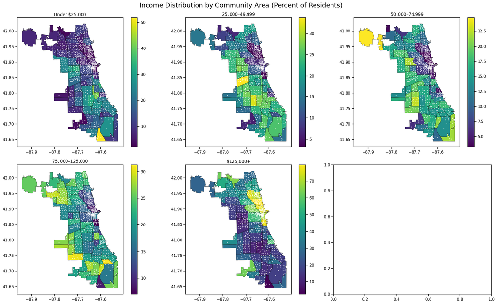

```python
bins = [
    ('pct_under_25k', 'Under $25,000'),
    ('pct_25_49k', '$25,000–$49,999'),
    ('pct_50_74k', '$50,000–$74,999'),
    ('pct_75_125k', '$75,000–$125,000'),
    ('pct_125_plus', '$125,000+')
]

fig, axes = plt.subplots(2, 3, figsize=(20, 12))
axes = axes.flatten()

for i, (col, label) in enumerate(bins):
    chicago_dem.plot(
        column=col,
        cmap='viridis',
        linewidth=0.4,
        edgecolor='black',
        legend=True,
        ax=axes[i]
    )
    axes[i].set_title(label)

    axes[i].scatter(stations_clean['Longitude'], stations_clean['Latitude'], s=3, alpha=0.5, color='white', marker='o')


fig.suptitle("Income Distribution by Community Area (Percent of Residents)", fontsize=18)
plt.tight_layout()
plt.show()
```

Chlorographs based on income in each community. These are little difficult to interpret, so I will make a different plot to analyze socioeconomic status per community.

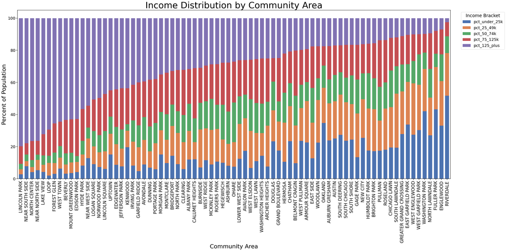

```python
plot_df = chicago_dem[[
    'Community Area',
    'pct_under_25k',
    'pct_25_49k',
    'pct_50_74k',
    'pct_75_125k',
    'pct_125_plus'
]].set_index('Community Area')

plot_df_sorted = plot_df.sort_values('pct_125_plus', ascending=False)

fig, ax = plt.subplots(figsize=(32, 16))

plot_df_sorted.plot(
    kind='bar',
    stacked=True,
    width=0.7,
    ax=ax
)

ax.set_ylabel('Percent of Population', fontsize=26)
ax.set_xlabel('Community Area', fontsize=26)
plt.title('Income Distribution by Community Area', fontsize = 40)

ax.set_xticklabels(ax.get_xticklabels(), fontsize=20, rotation=90)
ax.set_yticklabels(ax.get_yticklabels(), fontsize=18)

plt.legend(title='Income Bracket', bbox_to_anchor=(1.02, 1), loc='upper left', fontsize = 18, title_fontsize = 20)


plt.tight_layout()
plt.show()
```

Here is a readable plot that shows income in each community. It is sorted by the communities with the highest to lowest percentage of citizens who makes more than $125,000. Essentially, it shows the highest to lowest socioeconomic status neighborhoods.

##### 2.1.1.0.1 Converting Stations onto the Geographic Map of Chicago (more merging)

*By Jenna Krinsky*

```python
#I want to see how many stations are in each community
#used help of AI to understand how to spatial join stations to communities in Chicago

stations_gdf = gpd.GeoDataFrame(
    stations_clean,
    geometry=gpd.points_from_xy(stations_clean['Longitude'], stations_clean['Latitude']),
    crs="EPSG:4326"
)
chicago = chicago.to_crs(epsg=4326)
stations_with_community = gpd.sjoin(
    stations_gdf,
    chicago[['community', 'geometry']],  # only keep needed columns
    how='left',
    predicate='within'
)
```

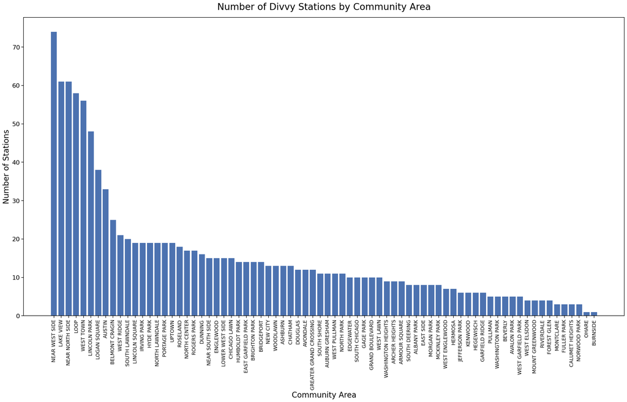

```python
#using method from class to count number of divvy bike stops per community

station_counts = (
    stations_with_community
    .groupby('community')
    .size()
    .sort_values(ascending=False)
)

fig, ax = plt.subplots(figsize=(28, 14))

ax.bar(
    station_counts.index,
    station_counts.values
)
ax.set_title('Number of Divvy Stations by Community Area', fontsize=24, pad=20)

ax.set_xlabel('Community Area', fontsize=20)
ax.set_ylabel('Number of Stations', fontsize=20)

ax.set_xticks(range(len(station_counts.index)));
ax.set_xticklabels(station_counts.index, rotation=90, fontsize=13);
ax.set_yticklabels(ax.get_yticks().astype(int), fontsize=16);
```

The above graph shows how many Divvy Bike stops are in each community.

### 2.1.2 Correlation of socioeconomic status to number of Divvy stations

*By Jenna Krinsky*

```python
#need to merge the # of stations/community with community demographic df

station2 = station_counts.reset_index()
station2.columns = ['community', 'n_stations']
#need it to be a df
```

```python
#making sure can merge on the community areas

chicago_dem['community'] = chicago_dem['community'].str.upper().str.strip()
station2['community'] = station2['community'].str.upper().str.strip()
```

```python
#merging the two datasets to see how many stations there are and the % of citizens who make over $125k in each community
chicago_dem = station2.merge(
    chicago_dem,
    on='community',
)

chicago_dem.head()
```

|  | community | n_stations | area_numbe | area_num_1 | shape_area | shape_len | geometry | community_name | Community Area | ACS Year | ... | Other Race | Multiracial | White Not Hispanic or Latino | Hispanic or Latino | Record ID | pct_under_25k | pct_25_49k | pct_50_74k | pct_75_125k | pct_125_plus |
| --- | --- | --- | --- | --- | --- | --- | --- | --- | --- | --- | --- | --- | --- | --- | --- | --- | --- | --- | --- | --- | --- |
| 0 | BURNSIDE | 1 | 47.0 | 47 | 1.699598e+07 | 18137.944253 | POLYGON ((-87.58737 41.72326, -87.58733 41.723... | BURNSIDE | BURNSIDE | 2023 | ... | 0 | 183 | 40 | 108 | 2023_BURNSIDE | 7.045455 | 23.636364 | 16.590909 | 21.818182 | 30.909091 |
| 1 | OHARE | 1 | 76.0 | 76 | 3.718356e+08 | 173625.984660 | MULTIPOLYGON (((-87.83658 41.9864, -87.83658 4... | OHARE | OHARE | 2023 | ... | 1,110 | 1,176 | 9,418 | 3,013 | 2023_OHARE | 7.533443 | 15.254635 | 24.689040 | 25.416569 | 27.106313 |
| 2 | MONTCLARE | 3 | 18.0 | 18 | 2.757639e+07 | 22404.852145 | POLYGON ((-87.78942 41.91751, -87.79152 41.918... | MONTCLARE | MONTCLARE | 2023 | ... | 3,851 | 1,398 | 4,683 | 7,515 | 2023_MONTCLARE | 9.743910 | 14.490943 | 15.927545 | 25.827608 | 34.009994 |
| 3 | NORWOOD PARK | 3 | 10.0 | 10 | 1.219591e+08 | 80368.374378 | POLYGON ((-87.78002 41.99741, -87.78049 41.997... | NORWOOD PARK | NORWOOD PARK | 2023 | ... | 1,759 | 3,819 | 27,986 | 7,802 | 2023_NORWOOD PARK | 7.270156 | 9.165488 | 10.749646 | 23.187176 | 49.627534 |
| 4 | CALUMET HEIGHTS | 3 | 48.0 | 48 | 4.882624e+07 | 32925.365871 | POLYGON ((-87.54568 41.72282, -87.546 41.72279... | CALUMET HEIGHTS | CALUMET HEIGHTS | 2023 | ... | 158 | 284 | 28 | 498 | 2023_CALUMET HEIGHTS | 12.168218 | 10.617029 | 14.856946 | 31.230610 | 31.127198 |

5 rows × 43 columns

```python
chicago_dem['n_stations'].corr(chicago_dem['pct_125_plus'])
```

```
np.float64(0.508685457885125)
```

The number of bikes in a community and the % of people who make more than $125k in each community has a moderate positive correlation at .51. This means that usually, wealthier neighborhoods have more Divvy bike stations.

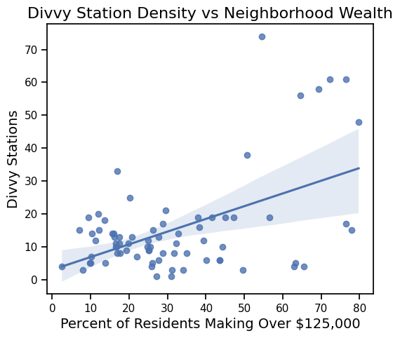

```python
plt.figure(figsize=(6, 5))

sns.regplot(
    data=chicago_dem,
    x='pct_125_plus',
    y='n_stations'
)

plt.xlabel('Percent of Residents Making Over $125,000', fontsize=14)
plt.ylabel('Divvy Stations', fontsize=14)
plt.title('Divvy Station Density vs Neighborhood Wealth', fontsize=16)
```

Close-up of corr between % of residents in a community making over 125k and number of Divvy bike stations in that community.

```python
race_cols = [
    'White', 'Black or African American',
    'American Indian or Alaska Native', 'Asian',
    'Native Hawaiian or Pacific Islander', 'Other Race', 'Multiracial',
    'White Not Hispanic or Latino', 'Hispanic or Latino'
]

# Turned out to be unecessary but now all cols with #s are ints/numeric
for col in race_cols:
    chicago_dem[col] = (
        chicago_dem[col]
        .astype(str)
        .str.replace(',', '', regex=True)
        .astype(float)
    )
```

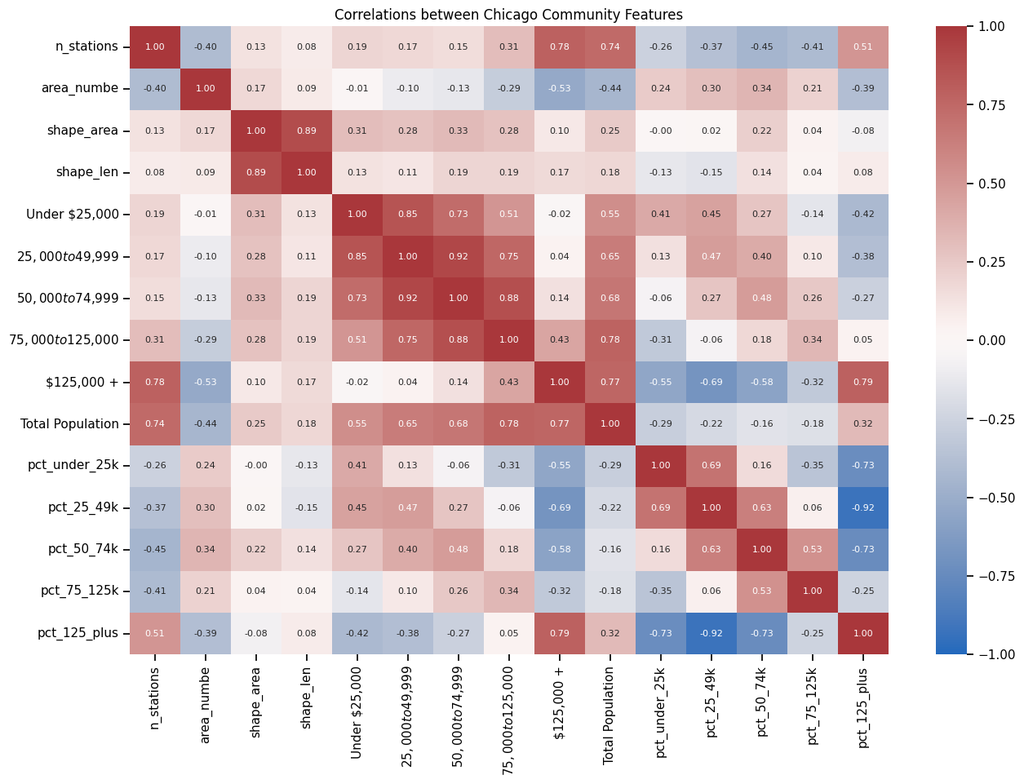

```python
chicago_num = chicago_dem.select_dtypes(include=['number'])
chicago_num = chicago_num.drop(["ACS Year", 'White', 'Black or African American',
    'American Indian or Alaska Native', 'Asian',
    'Native Hawaiian or Pacific Islander', 'Other Race', 'Multiracial',
    'White Not Hispanic or Latino', 'Hispanic or Latino'] , axis = 1)
matrix = chicago_num.corr()
plt.figure(figsize=(15, 10))

sns.heatmap(matrix, cmap='vlag', annot=True, fmt=".2f", vmin = -1, vmax=1, annot_kws={"size": 8});
plt.title("Correlations between Chicago Community Features")
```

Number of stations is positively correlated with % of 125k+ but negatively correlated with all other income groups. Also, total population and is generally similarly correlated to each income group (except $125k+), so that is not the only reason for more stations.

## 2.2 Alexa’s Analysis

### 2.2.1 Analysis 1

*By Alexa*

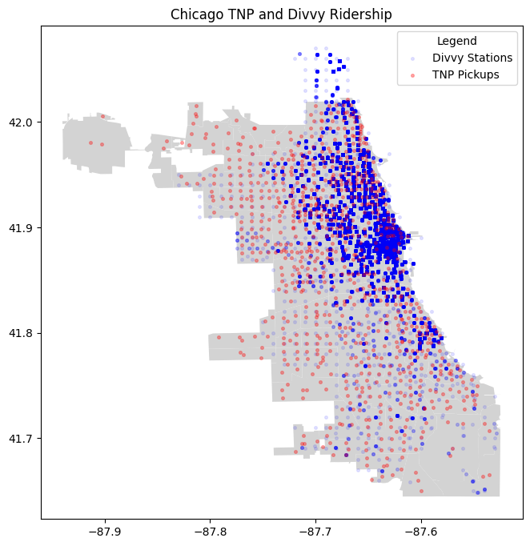

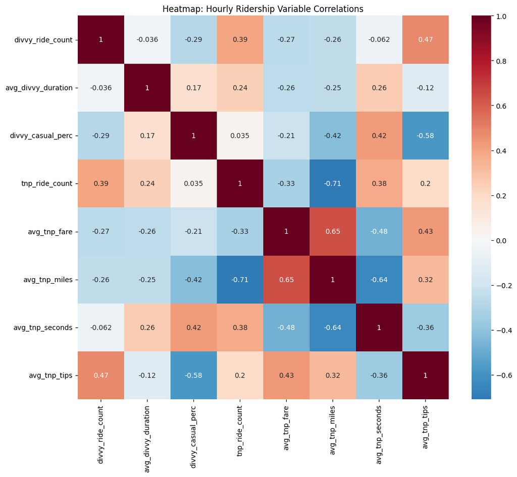

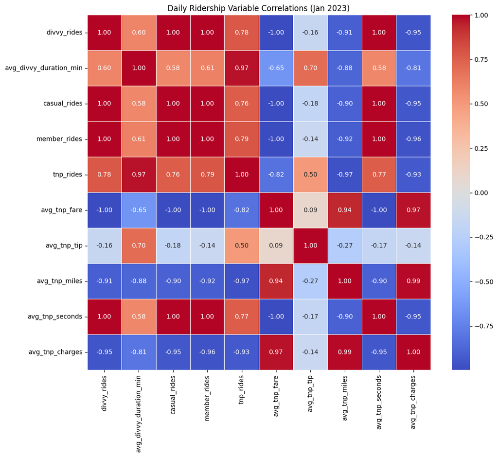

```
r  = 0.39267568550608956
```

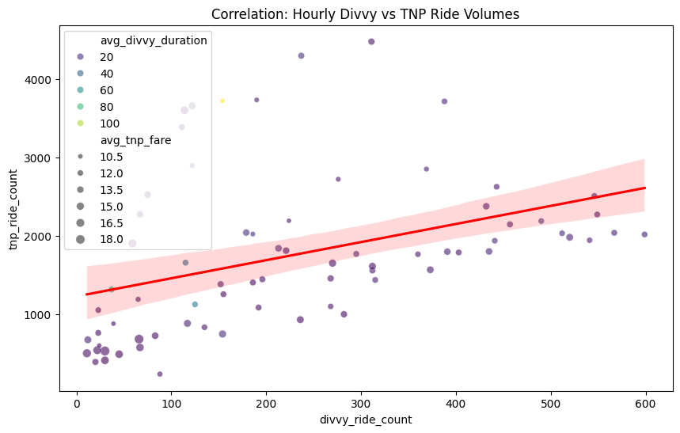

```python
# *** geoplotting ***
chi = gpd.read_file('geo_export_c5010bdc-6062-4b24-9554-b85a53f7b455.shp') # shapefile for boundaries
# sets of points
unique_lat_long_df = divvy.drop_duplicates(subset=['start_lat', 'start_lng'])
gdf_points1 = gpd.GeoDataFrame(unique_lat_long_df, geometry=gpd.points_from_xy(unique_lat_long_df.start_lng, unique_lat_long_df.start_lat)) # divvy stations
unique_lat_long_df2 = tnp.drop_duplicates(subset=['Pickup Centroid Latitude', 'Pickup Centroid Longitude'])
gdf_points2 = gpd.GeoDataFrame(unique_lat_long_df2, geometry=gpd.points_from_xy(unique_lat_long_df2['Pickup Centroid Longitude'], unique_lat_long_df2['Pickup Centroid Latitude'])) # tnp pickups
# Adding the tnp pickups to the plot
fig, ax = plt.subplots(figsize=(10, 8))
chi.plot(column = 'area_num_1', ax=ax, color = 'lightgray')
gdf_points1.plot(ax=ax, marker='o', markersize=7, color='blue', alpha=0.1, label = 'Divvy Stations')
gdf_points2.plot(ax=ax, marker='o', markersize=7, color='red', alpha=0.3, label = 'TNP Pickups')
ax.legend(title="Legend")
plt.title('Chicago TNP and Divvy Ridership');

 # *** Correlation Heatmap (hourly agg) ***
plt.figure(figsize=(12, 10))
sns.heatmap(merged_hourly.drop(columns=['hour_bin']).corr(), annot=True, cmap='RdBu_r', center=0)
plt.savefig('hourly_heatmap.png')
plt.title('Heatmap: Hourly Ridership Variable Correlations')

 # *** Correlation Heatmap (daily agg) ***
plt.figure(figsize=(12, 10))
sns.heatmap(corr_matrix, annot=True, cmap='coolwarm', fmt=".2f", linewidths=.5)
plt.title('Daily Ridership Variable Correlations (Jan 2023)')
plt.show()

# *** Scatter Plot/lm plot ***
plt.figure(figsize=(10, 6))
sns.scatterplot(data=merged_hourly, x='divvy_ride_count', y='tnp_ride_count',
                size='avg_tnp_fare', hue='avg_divvy_duration', palette='viridis', alpha=0.6)
sns.regplot(data=merged_hourly, x='divvy_ride_count', y='tnp_ride_count', scatter=False, color='red')
plt.title('Correlation: Hourly Divvy vs TNP Ride Volumes')
plt.savefig('hourly_scatter_populated.png')
correlation, _ = pearsonr(merged_hourly['divvy_ride_count'], merged_hourly['tnp_ride_count'])
print(f'r  = {correlation}')
```

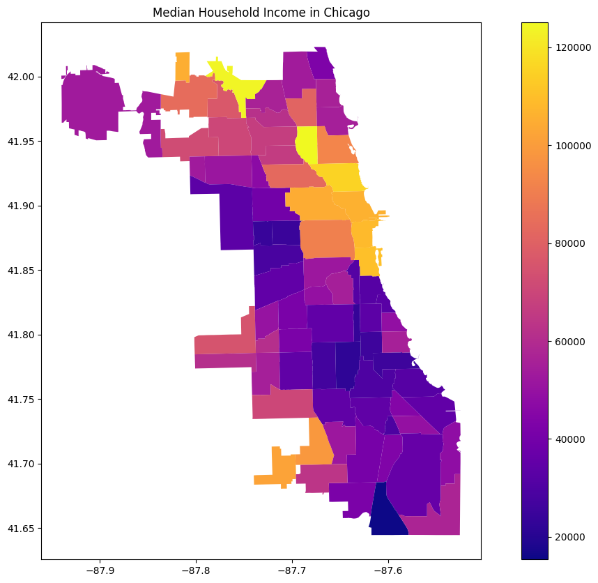

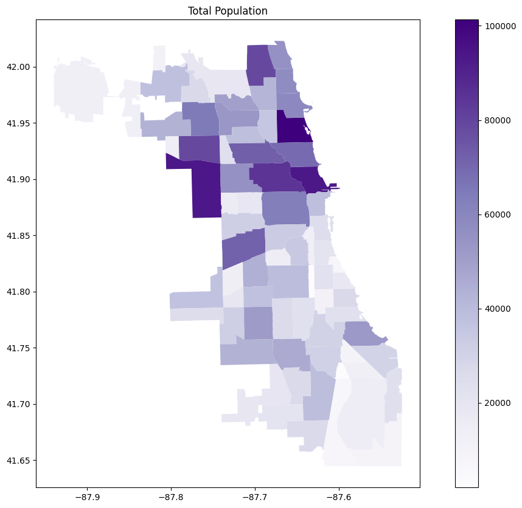

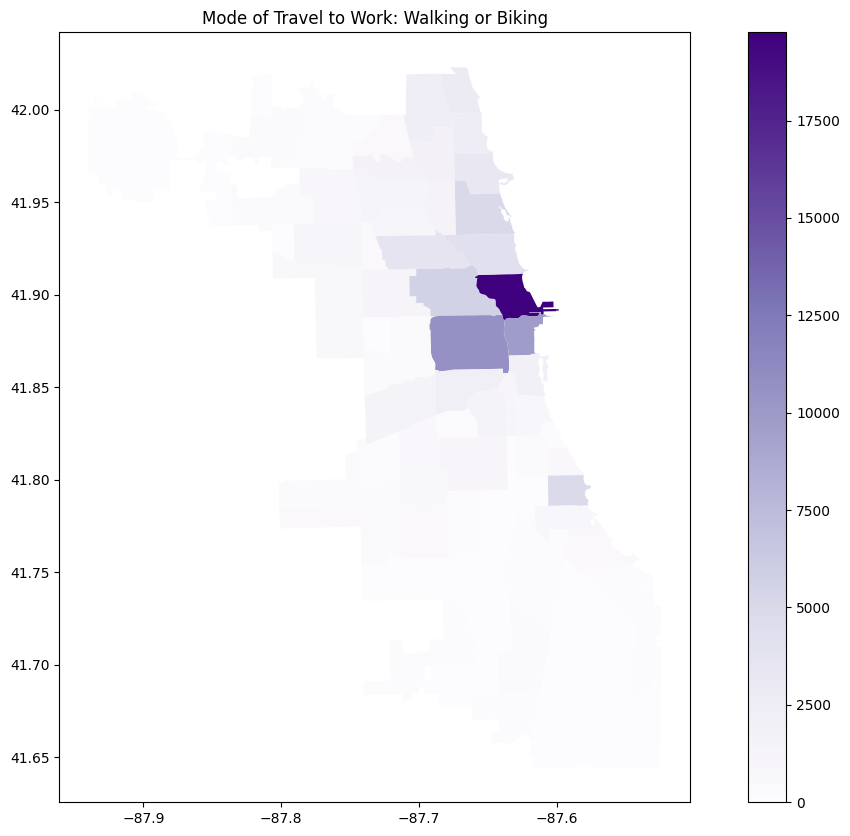

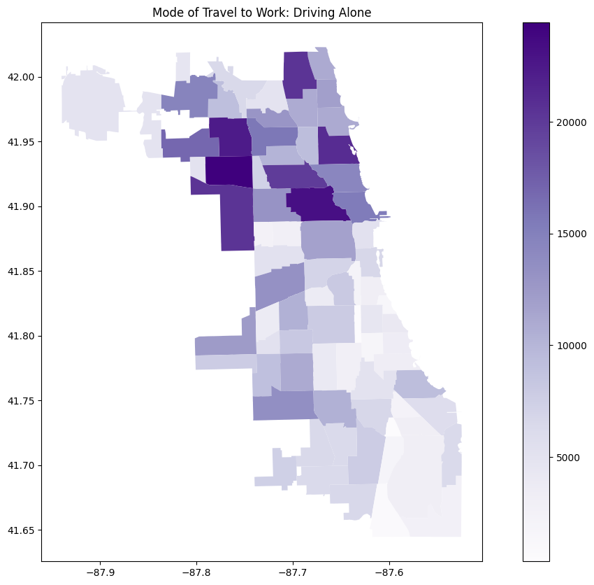

```python
# *** choropleths ***
chipop = gpd.read_file('Chicago_2020_sdoh.shp') # data

# median household income
fig, ax = plt.subplots(figsize=(15, 10))
chipop.plot(column='MEDINC', ax=ax, legend=True, cmap='plasma') # using column median income
plt.title('Median Household Income in Chicago')

# total population
fig, ax = plt.subplots(figsize=(15, 10))
chipop.plot(column='TOT_POP', ax=ax, legend=True, cmap='Purples') # using column total population
plt.title('Total Population')

# walk/bike to work
fig, ax = plt.subplots(figsize=(15, 10))
chipop.plot(column='WALK_BIKE', ax=ax, legend=True, cmap='Purples') # using column walk/bike (people who walk or bike to work)
plt.title('Mode of Travel to Work: Walking or Biking')

# drive alone to work
fig, ax = plt.subplots(figsize=(15, 10))
chipop.plot(column='DROVE_AL', ax=ax, legend=True, cmap='Purples') # using column drove alone (people who drive alone to work)
plt.title('Mode of Travel to Work: Driving Alone')
```

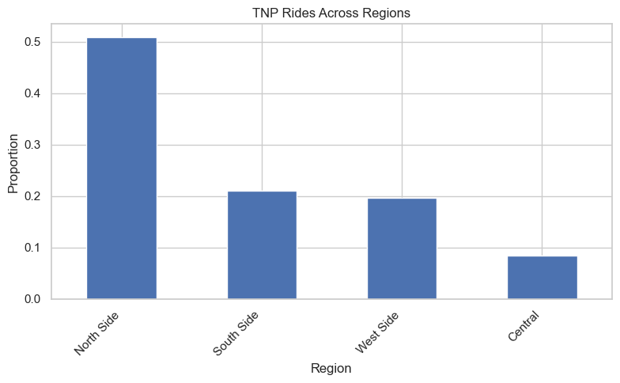

```python
# rides across region
category_counts = tnp['region'].value_counts(normalize=True)
ax = category_counts.plot(kind='bar', figsize=(8, 5))

# Add labels and a title for clarity
ax.set_xlabel('Region')
ax.set_ylabel('Proportion')
ax.set_title('TNP Rides Across Regions')

# Rotate x-axis labels if needed for better readability
plt.xticks(rotation=45, ha='right')

# Display the plot
plt.tight_layout() # Adjust layout to prevent labels from overlapping
plt.show()
```

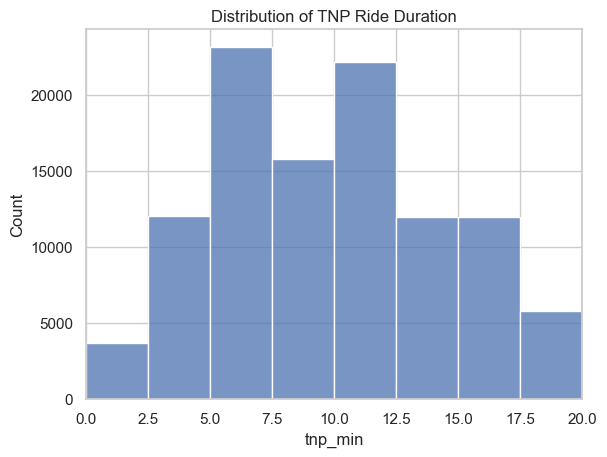

```
median = 11.0
mean = 12.369139047679372
Mean duration (filtered): 9.26
Median duration (filtered): 7.00
Percentage of trips within 0-60 mins: 95.9%
```

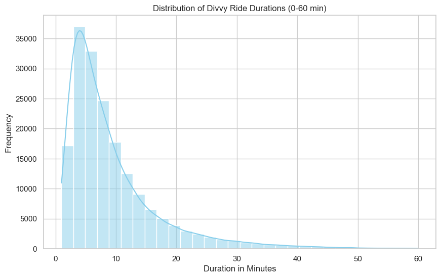

```python
# *** histograms ***

# tnp ride duration
sns.histplot(data=tnp, x = 'tnp_min', bins=24)
# Adjust x-axis limits
plt.xlim(0, 20)
plt.title('Distribution of TNP Ride Duration')
plt.show()
print(f'median = {tnp['tnp_min'].median()}')
print(f'mean = {tnp['tnp_min'].mean()}')

# divvy ride duration
filtered_df = divvy[(divvy['min'] > 0) & (divvy['min'] <= 60)]
# Create the histogram
sns.set_theme(style="whitegrid")
plt.figure(figsize=(10, 6))
sns.histplot(filtered_df['min'], bins=30, kde=True, color='skyblue')
# Labels and title
plt.title('Distribution of Divvy Ride Durations (0-60 min)')
plt.xlabel('Duration in Minutes')
plt.ylabel('Frequency')
# Output some stats for context in response
print(f"Mean duration (filtered): {filtered_df['min'].mean():.2f}")
print(f"Median duration (filtered): {filtered_df['min'].median():.2f}")
print(f"Percentage of trips within 0-60 mins: {(len(filtered_df)/len(divvy))*100:.1f}%")
```

## 2.3 Grace’s Analysis

### 2.3.1 1: Correlation Matrix Overall (unbinned, both per cap and not per cap)

*By Grace Gormley*

I’m using unbinned since having 77 rows gives more robust correlation estimates than only 9.

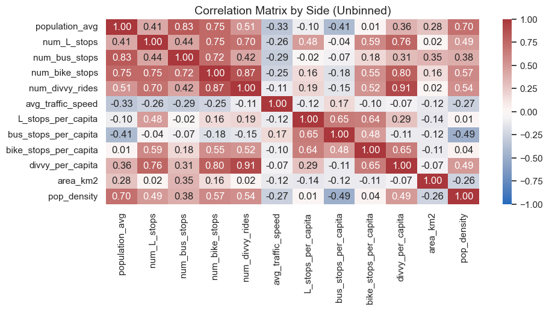

```python
fig, (ax1) = plt.subplots(1, figsize=(10, 4))

sns.heatmap(merged.select_dtypes(include='number').corr(), cmap='vlag', annot=True, fmt=".2f", ax=ax1, vmin = -1, vmax=1) #picked vlag since that emphazises strong negative and positive corr
ax1.set_title('Correlation Matrix by Side (Unbinned)', fontsize=14);
```

#### 2.3.1.1 Interesting / Unexpected Things

1. Traffic speed is almost unrelated to the transit infrastructure per capita and to divvy bike rides. This seems probably inaccurate (meaning unfortunately I may just not have enough traffic intel).
2. Population density is related to divvy rides (0.49) but not to bike stops (0.04)

Let’s dive deeper into question 2

#### 2.3.1.2 Question 2: Population Density vs Divvy Rides

I’ll make a ratio of # of rides vs # of stations and graph that over population density.

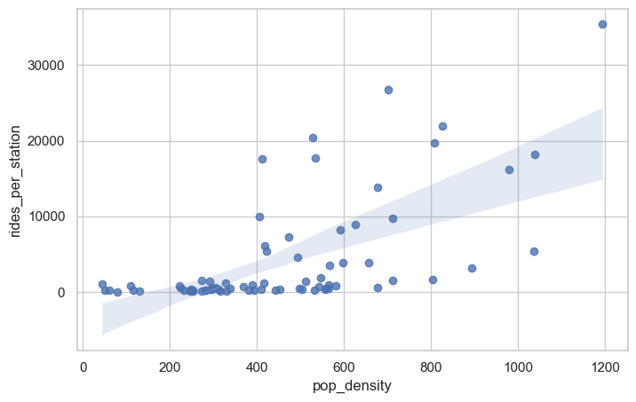

```python
merged['rides_per_station'] = (merged['num_divvy_rides'] / merged['num_bike_stops'])

sns.regplot(data=merged,x='pop_density',y='rides_per_station')

# Infrastructure mismatch -  the higher pop density leads to overused stations
```

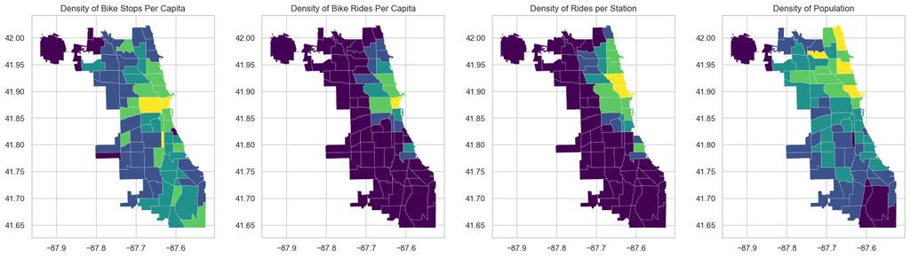

```python
chicago_merge = chicago.merge(merged, on=['community'], how='left')

fig, axes = plt.subplots(1, 4, figsize=(18, 5), sharex=False, sharey=False)

#Bike stops
chicago_merge.plot(
    column='bike_stops_per_capita',
    legend=False,
    cmap='viridis',
    scheme='NaturalBreaks',
    ax=axes[0], linewidth=0.2)
axes[0].set_title("Density of Bike Stops Per Capita")

#Bike Rides
chicago_merge.plot(
    column='divvy_per_capita',
    ax=axes[1],
    legend=False,
    cmap='viridis',
    scheme='NaturalBreaks', linewidth=0.2
)
axes[1].set_title("Density of Bike Rides Per Capita")

#pop_density
chicago_merge.plot(
    column='pop_density',
   ax=axes[3],
    legend=False,
    cmap='viridis',
    scheme='NaturalBreaks', linewidth=0.2
)
axes[3].set_title("Density of Population")


#I need to wrangle rides per station a bit:
chicago_merge['rides_by_station_numeric'] = pd.to_numeric(chicago_merge['rides_per_station'], errors='coerce')
chicago_merge = chicago_merge.replace([np.inf, -np.inf], np.nan)
chicago_merge = chicago_merge.dropna(subset=['rides_by_station_numeric'])

#rides per station density
chicago_merge.plot(
    column='rides_by_station_numeric',
    ax=axes[2],
    legend=False,
    cmap='viridis',
    scheme='NaturalBreaks', linewidth=0.2
)
axes[2].set_title("Density of Rides per Station")

plt.tight_layout();
```

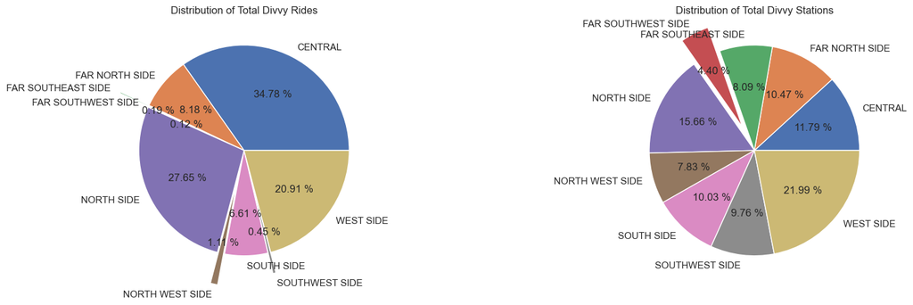

```python
fig, axes = plt.subplots(1, 2, figsize=(18, 5), sharex=False, sharey=False)

explode1 = (0, 0, 0.3, 0, 0, 0.3, 0, 0.2, 0)
axes[0].pie(side_data.Total_Divvy_Rides, labels=side_data.side, explode =explode1, autopct='%.2f %%')
axes[0].set_title("Distribution of Total Divvy Rides")


explode2 = (0, 0, 0, 0.25, 0, 0, 0, 0, 0)
axes[1].pie(side_data.Total_Divvy_Stations, labels=side_data.side, explode =explode2, autopct='%.2f %%')
axes[1].set_title("Distribution of Total Divvy Stations")

plt.tight_layout();
```

Yet another, even clearer (though the graph is a bit ugly) visualization are these pie charts. The bike rides are not even at all, but bike stations are relatively even.

#### 2.3.1.4 Potential Suggestion:

Instead of a general spread, Divvy maybe should aim for strategic placement of stops, aiming to add more in areas where there is more need AND (crucially) in areas where there is POTENTIAL NEED. So where is there potential need?